# Exploratory Data Analysis of Solar Energy Data

Author

JBS

# 1 Overview

The dataset under consideration comprises daily solar energy readings from various locations within a large facility or campus over the course of one year. Each location’s solar energy data has been recorded, offering an invaluable resource for understanding energy consumption and production patterns. This report aims to provide an exploratory data analysis (EDA) of this dataset, uncovering key insights and trends. The data contains 365 rows and 64 columns, where each row represents a day, and each column (except for the DATE) represents a specific location or area within the facility. The columns include

- DATE: The date of the recorded data.
- SKH 1 (MANDIR) to SSS RJY 2: Locations or areas within the facility with their respective solar energy readings.

# 2 Mapping Solar Synergy: Insights from Correlation Analysis Across Multiple Locations

## 2.1 Correlation Analysis

To understand the relationships between the solar energy readings at different locations, we performed a correlation analysis. The correlation matrix provides insights into how the solar energy data from various locations are related to each other.

#### 2.1.0.2 Moderately Correlated Pairs

1. **N1 and N3 & N4 (0.862***):** This correlation suggests a strong relationship between the solar energy readings of these areas, although not as strong as the highest correlations observed.
2. **R1 and N9 & N9 A (0.836***):** This indicates a significant correlation, suggesting a shared factor influencing the solar energy readings in these areas.
3. **W3 & 4 (A) and W3 & 4 (B) (0.928***):** A strong correlation between the segments of W3 & 4 suggests similar patterns in solar energy readings, likely due to similar solar exposure or usage.
4. **SHANTHI BHAVAN and LADIES SEVADAL (0.729***):** This correlation is indicative of a moderate relationship between the solar energy readings at these locations, possibly due to shared operational schedules or proximity.

#### 2.1.0.4 Negative or No Correlation

**Correlation Matrix**

Package used: Hmisc; PB-Perfect

|  | N1 | N2 | N3 &N4 | N4 AAC& DAC | N5&NAS(CANTEEN) | N6 | N7 | N8 | N9 &N9 A | R1 | R2 | R3 | R4 | R5 | W1&2(A) | W1&2(B) | W 3&4(A) | W 3&4(B) | W 5&6(A) | W 5&6 (B) | W 7&8 A | W 7&8 B | W9 | S1 A | S1 B | S(1&2) | S3 | S(7to8) | PATASALA | … |
| --- | --- | --- | --- | --- | --- | --- | --- | --- | --- | --- | --- | --- | --- | --- | --- | --- | --- | --- | --- | --- | --- | --- | --- | --- | --- | --- | --- | --- | --- | --- |
| N1 | 1.000 | 0.911*** | 0.862*** | 0.945*** | 0.845*** | 0.910*** | 0.904*** | 0.835*** | 0.916*** | 0.850*** | 0.920*** | 0.927*** | 0.918*** | 0.839*** | 0.865*** | 0.783*** | 0.784*** | 0.859*** | 0.887*** | 0.894*** | 0.749*** | 0.823*** | 0.906*** | 0.867*** | 0.837*** | 0.712*** | 0.446*** | 0.801*** | 0.869*** | … |
| N2 | 0.911*** | 1.000 | 0.843*** | 0.928*** | 0.834*** | 0.916*** | 0.901*** | 0.800*** | 0.896*** | 0.847*** | 0.917*** | 0.921*** | 0.908*** | 0.822*** | 0.868*** | 0.792*** | 0.809*** | 0.863*** | 0.895*** | 0.902*** | 0.770*** | 0.845*** | 0.912*** | 0.881*** | 0.890*** | 0.759*** | 0.525*** | 0.831*** | 0.870*** | … |
| N3 &N4 | 0.862*** | 0.843*** | 1.000 | 0.878*** | 0.785*** | 0.864*** | 0.842*** | 0.795*** | 0.859*** | 0.803*** | 0.859*** | 0.862*** | 0.838*** | 0.772*** | 0.798*** | 0.733*** | 0.731*** | 0.796*** | 0.816*** | 0.829*** | 0.702*** | 0.773*** | 0.842*** | 0.801*** | 0.785*** | 0.671*** | 0.455*** | 0.763*** | 0.804*** | … |
| N4 AAC& DAC | 0.945*** | 0.928*** | 0.878*** | 1.000 | 0.890*** | 0.944*** | 0.934*** | 0.836*** | 0.942*** | 0.873*** | 0.951*** | 0.953*** | 0.940*** | 0.859*** | 0.891*** | 0.824*** | 0.817*** | 0.892*** | 0.905*** | 0.936*** | 0.797*** | 0.875*** | 0.945*** | 0.909*** | 0.876*** | 0.781*** | 0.528*** | 0.872*** | 0.901*** | … |
| N5&NAS(CANTEEN) | 0.845*** | 0.834*** | 0.785*** | 0.890*** | 1.000 | 0.843*** | 0.860*** | 0.720*** | 0.847*** | 0.823*** | 0.875*** | 0.871*** | 0.863*** | 0.758*** | 0.815*** | 0.733*** | 0.742*** | 0.810*** | 0.852*** | 0.881*** | 0.745*** | 0.838*** | 0.884*** | 0.868*** | 0.815*** | 0.765*** | 0.559*** | 0.831*** | 0.830*** | … |
| N6 | 0.910*** | 0.916*** | 0.864*** | 0.944*** | 0.843*** | 1.000 | 0.918*** | 0.810*** | 0.916*** | 0.856*** | 0.931*** | 0.932*** | 0.925*** | 0.858*** | 0.873*** | 0.796*** | 0.793*** | 0.873*** | 0.887*** | 0.920*** | 0.780*** | 0.854*** | 0.927*** | 0.895*** | 0.856*** | 0.768*** | 0.517*** | 0.850*** | 0.881*** | … |
| N7 | 0.904*** | 0.901*** | 0.842*** | 0.934*** | 0.860*** | 0.918*** | 1.000 | 0.811*** | 0.902*** | 0.856*** | 0.926*** | 0.925*** | 0.917*** | 0.835*** | 0.867*** | 0.798*** | 0.810*** | 0.871*** | 0.885*** | 0.925*** | 0.788*** | 0.866*** | 0.927*** | 0.894*** | 0.858*** | 0.786*** | 0.545*** | 0.861*** | 0.878*** | … |
| N8 | 0.835*** | 0.800*** | 0.795*** | 0.836*** | 0.720*** | 0.810*** | 0.811*** | 1.000 | 0.797*** | 0.735*** | 0.807*** | 0.801*** | 0.803*** | 0.800*** | 0.743*** | 0.681*** | 0.651*** | 0.749*** | 0.771*** | 0.738*** | 0.596*** | 0.702*** | 0.776*** | 0.727*** | 0.733*** | 0.529*** | 0.292*** | 0.658*** | 0.750*** | … |
| N9 &N9 A | 0.916*** | 0.896*** | 0.859*** | 0.942*** | 0.847*** | 0.916*** | 0.902*** | 0.797*** | 1.000 | 0.836*** | 0.918*** | 0.919*** | 0.906*** | 0.806*** | 0.861*** | 0.785*** | 0.783*** | 0.862*** | 0.875*** | 0.915*** | 0.764*** | 0.834*** | 0.910*** | 0.890*** | 0.854*** | 0.766*** | 0.508*** | 0.877*** | 0.887*** | … |
| R1 | 0.850*** | 0.847*** | 0.803*** | 0.873*** | 0.823*** | 0.856*** | 0.856*** | 0.735*** | 0.836*** | 1.000 | 0.855*** | 0.891*** | 0.853*** | 0.783*** | 0.818*** | 0.760*** | 0.778*** | 0.821*** | 0.857*** | 0.872*** | 0.751*** | 0.833*** | 0.890*** | 0.845*** | 0.804*** | 0.745*** | 0.594*** | 0.800*** | 0.827*** | … |
| R2 | 0.920*** | 0.917*** | 0.859*** | 0.951*** | 0.875*** | 0.931*** | 0.926*** | 0.807*** | 0.918*** | 0.855*** | 1.000 | 0.963*** | 0.929*** | 0.842*** | 0.879*** | 0.808*** | 0.804*** | 0.881*** | 0.922*** | 0.937*** | 0.811*** | 0.893*** | 0.956*** | 0.914*** | 0.880*** | 0.795*** | 0.551*** | 0.866*** | 0.899*** | … |
| R3 | 0.927*** | 0.921*** | 0.862*** | 0.953*** | 0.871*** | 0.932*** | 0.925*** | 0.801*** | 0.919*** | 0.891*** | 0.963*** | 1.000 | 0.928*** | 0.843*** | 0.882*** | 0.820*** | 0.813*** | 0.882*** | 0.928*** | 0.942*** | 0.813*** | 0.892*** | 0.960*** | 0.911*** | 0.882*** | 0.797*** | 0.556*** | 0.865*** | 0.903*** | … |
| R4 | 0.918*** | 0.908*** | 0.838*** | 0.940*** | 0.863*** | 0.925*** | 0.917*** | 0.803*** | 0.906*** | 0.853*** | 0.929*** | 0.928*** | 1.000 | 0.833*** | 0.875*** | 0.800*** | 0.803*** | 0.880*** | 0.889*** | 0.927*** | 0.788*** | 0.859*** | 0.932*** | 0.902*** | 0.845*** | 0.785*** | 0.531*** | 0.860*** | 0.890*** | … |
| R5 | 0.839*** | 0.822*** | 0.772*** | 0.859*** | 0.758*** | 0.858*** | 0.835*** | 0.800*** | 0.806*** | 0.783*** | 0.842*** | 0.843*** | 0.833*** | 1.000 | 0.789*** | 0.740*** | 0.705*** | 0.785*** | 0.810*** | 0.812*** | 0.696*** | 0.763*** | 0.842*** | 0.798*** | 0.763*** | 0.663*** | 0.428*** | 0.720*** | 0.797*** | … |
| W1&2(A) | 0.865*** | 0.868*** | 0.798*** | 0.891*** | 0.815*** | 0.873*** | 0.867*** | 0.743*** | 0.861*** | 0.818*** | 0.879*** | 0.882*** | 0.875*** | 0.789*** | 1.000 | 0.898*** | 0.916*** | 0.984*** | 0.842*** | 0.910*** | 0.712*** | 0.821*** | 0.883*** | 0.887*** | 0.842*** | 0.786*** | 0.548*** | 0.851*** | 0.871*** | … |
| W1&2(B) | 0.783*** | 0.792*** | 0.733*** | 0.824*** | 0.733*** | 0.796*** | 0.798*** | 0.681*** | 0.785*** | 0.760*** | 0.808*** | 0.820*** | 0.800*** | 0.740*** | 0.898*** | 1.000 | 0.886*** | 0.910*** | 0.774*** | 0.841*** | 0.680*** | 0.761*** | 0.827*** | 0.817*** | 0.782*** | 0.767*** | 0.547*** | 0.812*** | 0.810*** | … |
| W 3&4(A) | 0.784*** | 0.809*** | 0.731*** | 0.817*** | 0.742*** | 0.793*** | 0.810*** | 0.651*** | 0.783*** | 0.778*** | 0.804*** | 0.813*** | 0.803*** | 0.705*** | 0.916*** | 0.886*** | 1.000 | 0.928*** | 0.774*** | 0.856*** | 0.686*** | 0.782*** | 0.831*** | 0.829*** | 0.777*** | 0.803*** | 0.594*** | 0.837*** | 0.809*** | … |
| W 3&4(B) | 0.859*** | 0.863*** | 0.796*** | 0.892*** | 0.810*** | 0.873*** | 0.871*** | 0.749*** | 0.862*** | 0.821*** | 0.881*** | 0.882*** | 0.880*** | 0.785*** | 0.984*** | 0.910*** | 0.928*** | 1.000 | 0.842*** | 0.916*** | 0.718*** | 0.827*** | 0.889*** | 0.895*** | 0.849*** | 0.801*** | 0.552*** | 0.868*** | 0.877*** | … |
| W 5&6(A) | 0.887*** | 0.895*** | 0.816*** | 0.905*** | 0.852*** | 0.887*** | 0.885*** | 0.771*** | 0.875*** | 0.857*** | 0.922*** | 0.928*** | 0.889*** | 0.810*** | 0.842*** | 0.774*** | 0.774*** | 0.842*** | 1.000 | 0.892*** | 0.791*** | 0.860*** | 0.917*** | 0.868*** | 0.848*** | 0.756*** | 0.530*** | 0.815*** | 0.862*** | … |
| W 5&6 (B) | 0.894*** | 0.902*** | 0.829*** | 0.936*** | 0.881*** | 0.920*** | 0.925*** | 0.738*** | 0.915*** | 0.872*** | 0.937*** | 0.942*** | 0.927*** | 0.812*** | 0.910*** | 0.841*** | 0.856*** | 0.916*** | 0.892*** | 1.000 | 0.827*** | 0.886*** | 0.955*** | 0.955*** | 0.882*** | 0.878*** | 0.645*** | 0.929*** | 0.915*** | … |
| W 7&8 A | 0.749*** | 0.770*** | 0.702*** | 0.797*** | 0.745*** | 0.780*** | 0.788*** | 0.596*** | 0.764*** | 0.751*** | 0.811*** | 0.813*** | 0.788*** | 0.696*** | 0.712*** | 0.680*** | 0.686*** | 0.718*** | 0.791*** | 0.827*** | 1.000 | 0.776*** | 0.836*** | 0.804*** | 0.753*** | 0.773*** | 0.589*** | 0.792*** | 0.725*** | … |
| W 7&8 B | 0.823*** | 0.845*** | 0.773*** | 0.875*** | 0.838*** | 0.854*** | 0.866*** | 0.702*** | 0.834*** | 0.833*** | 0.893*** | 0.892*** | 0.859*** | 0.763*** | 0.821*** | 0.761*** | 0.782*** | 0.827*** | 0.860*** | 0.886*** | 0.776*** | 1.000 | 0.905*** | 0.863*** | 0.830*** | 0.778*** | 0.563*** | 0.831*** | 0.831*** | … |
| W9 | 0.906*** | 0.912*** | 0.842*** | 0.945*** | 0.884*** | 0.927*** | 0.927*** | 0.776*** | 0.910*** | 0.890*** | 0.956*** | 0.960*** | 0.932*** | 0.842*** | 0.883*** | 0.827*** | 0.831*** | 0.889*** | 0.917*** | 0.955*** | 0.836*** | 0.905*** | 1.000 | 0.930*** | 0.874*** | 0.854*** | 0.610*** | 0.897*** | 0.904*** | … |
| S1 A | 0.867*** | 0.881*** | 0.801*** | 0.909*** | 0.868*** | 0.895*** | 0.894*** | 0.727*** | 0.890*** | 0.845*** | 0.914*** | 0.911*** | 0.902*** | 0.798*** | 0.887*** | 0.817*** | 0.829*** | 0.895*** | 0.868*** | 0.955*** | 0.804*** | 0.863*** | 0.930*** | 1.000 | 0.914*** | 0.891*** | 0.629*** | 0.912*** | 0.944*** | … |
| S1 B | 0.837*** | 0.890*** | 0.785*** | 0.876*** | 0.815*** | 0.856*** | 0.858*** | 0.733*** | 0.854*** | 0.804*** | 0.880*** | 0.882*** | 0.845*** | 0.763*** | 0.842*** | 0.782*** | 0.777*** | 0.849*** | 0.848*** | 0.882*** | 0.753*** | 0.830*** | 0.874*** | 0.914*** | 1.000 | 0.795*** | 0.527*** | 0.842*** | 0.912*** | … |
| S(1&2) | 0.712*** | 0.759*** | 0.671*** | 0.781*** | 0.765*** | 0.768*** | 0.786*** | 0.529*** | 0.766*** | 0.745*** | 0.795*** | 0.797*** | 0.785*** | 0.663*** | 0.786*** | 0.767*** | 0.803*** | 0.801*** | 0.756*** | 0.878*** | 0.773*** | 0.778*** | 0.854*** | 0.891*** | 0.795*** | 1.000 | 0.717*** | 0.883*** | 0.836*** | … |
| S3 | 0.446*** | 0.525*** | 0.455*** | 0.528*** | 0.559*** | 0.517*** | 0.545*** | 0.292*** | 0.508*** | 0.594*** | 0.551*** | 0.556*** | 0.531*** | 0.428*** | 0.548*** | 0.547*** | 0.594*** | 0.552*** | 0.530*** | 0.645*** | 0.589*** | 0.563*** | 0.610*** | 0.629*** | 0.527*** | 0.717*** | 1.000 | 0.692*** | 0.561*** | … |
| S(7to8) | 0.801*** | 0.831*** | 0.763*** | 0.872*** | 0.831*** | 0.850*** | 0.861*** | 0.658*** | 0.877*** | 0.800*** | 0.866*** | 0.865*** | 0.860*** | 0.720*** | 0.851*** | 0.812*** | 0.837*** | 0.868*** | 0.815*** | 0.929*** | 0.792*** | 0.831*** | 0.897*** | 0.912*** | 0.842*** | 0.883*** | 0.692*** | 1.000 | 0.864*** | … |
| PATASALA | 0.869*** | 0.870*** | 0.804*** | 0.901*** | 0.830*** | 0.881*** | 0.878*** | 0.750*** | 0.887*** | 0.827*** | 0.899*** | 0.903*** | 0.890*** | 0.797*** | 0.871*** | 0.810*** | 0.809*** | 0.877*** | 0.862*** | 0.915*** | 0.725*** | 0.831*** | 0.904*** | 0.944*** | 0.912*** | 0.836*** | 0.561*** | 0.864*** | 1.000 | … |
| SHED 1TO 8 | 0.686*** | 0.738*** | 0.744*** | 0.769*** | 0.729*** | 0.788*** | 0.771*** | 0.557*** | 0.739*** | 0.729*** | 0.767*** | 0.769*** | 0.759*** | 0.658*** | 0.749*** | 0.734*** | 0.771*** | 0.765*** | 0.720*** | 0.836*** | 0.733*** | 0.760*** | 0.818*** | 0.808*** | 0.715*** | 0.837*** | 0.660*** | 0.835*** | 0.755*** | … |
| LADIES SEVADAL | 0.929*** | 0.928*** | 0.856*** | 0.955*** | 0.863*** | 0.939*** | 0.931*** | 0.769*** | 0.927*** | 0.866*** | 0.952*** | 0.956*** | 0.935*** | 0.832*** | 0.893*** | 0.821*** | 0.816*** | 0.886*** | 0.917*** | 0.946*** | 0.822*** | 0.874*** | 0.949*** | 0.917*** | 0.889*** | 0.814*** | 0.586*** | 0.876*** | 0.909*** | … |
| SHANTHI BHAVAN | 0.715*** | 0.734*** | 0.657*** | 0.740*** | 0.668*** | 0.726*** | 0.746*** | 0.561*** | 0.691*** | 0.708*** | 0.734*** | 0.743*** | 0.738*** | 0.659*** | 0.747*** | 0.717*** | 0.792*** | 0.756*** | 0.697*** | 0.768*** | 0.648*** | 0.717*** | 0.765*** | 0.742*** | 0.658*** | 0.729*** | 0.519*** | 0.731*** | 0.717*** | … |
| IT OFFICE | 0.761*** | 0.784*** | 0.717*** | 0.815*** | 0.753*** | 0.843*** | 0.807*** | 0.615*** | 0.829*** | 0.740*** | 0.816*** | 0.817*** | 0.812*** | 0.679*** | 0.797*** | 0.735*** | 0.734*** | 0.805*** | 0.778*** | 0.868*** | 0.743*** | 0.788*** | 0.825*** | 0.853*** | 0.811*** | 0.786*** | 0.626*** | 0.896*** | 0.817*** | … |
| SSSC OFFICE | 0.782*** | 0.798*** | 0.742*** | 0.824*** | 0.740*** | 0.807*** | 0.810*** | 0.658*** | 0.794*** | 0.775*** | 0.822*** | 0.826*** | 0.802*** | 0.701*** | 0.762*** | 0.685*** | 0.699*** | 0.759*** | 0.786*** | 0.819*** | 0.717*** | 0.767*** | 0.820*** | 0.790*** | 0.770*** | 0.704*** | 0.504*** | 0.757*** | 0.784*** | … |
| PSN STP | 0.620*** | 0.578*** | 0.542*** | 0.606*** | 0.552*** | 0.590*** | 0.583*** | 0.654*** | 0.586*** | 0.556*** | 0.575*** | 0.559*** | 0.635*** | 0.637*** | 0.560*** | 0.513*** | 0.549*** | 0.580*** | 0.532*** | 0.555*** | 0.426*** | 0.504*** | 0.595*** | 0.561*** | 0.417*** | 0.451*** | 0.175*** | 0.491*** | 0.545*** | … |
| PLANETORIUM & STP &PSN1 | 0.649*** | 0.705*** | 0.606*** | 0.711*** | 0.716*** | 0.711*** | 0.716*** | 0.540*** | 0.698*** | 0.679*** | 0.731*** | 0.722*** | 0.737*** | 0.628*** | 0.704*** | 0.668*** | 0.689*** | 0.717*** | 0.721*** | 0.784*** | 0.716*** | 0.730*** | 0.784*** | 0.774*** | 0.679*** | 0.776*** | 0.610*** | 0.770*** | 0.726*** | … |
| CHAITANYA | 0.654*** | 0.663*** | 0.604*** | 0.691*** | 0.653*** | 0.669*** | 0.677*** | 0.538*** | 0.666*** | 0.631*** | 0.692*** | 0.696*** | 0.681*** | 0.592*** | 0.666*** | 0.647*** | 0.639*** | 0.674*** | 0.679*** | 0.726*** | 0.644*** | 0.649*** | 0.706*** | 0.701*** | 0.658*** | 0.678*** | 0.474*** | 0.698*** | 0.702*** | … |
| RADIO SAI AUDIO | 0.911*** | 0.895*** | 0.841*** | 0.933*** | 0.835*** | 0.915*** | 0.902*** | 0.841*** | 0.935*** | 0.839*** | 0.913*** | 0.910*** | 0.904*** | 0.850*** | 0.885*** | 0.813*** | 0.815*** | 0.892*** | 0.867*** | 0.906*** | 0.746*** | 0.834*** | 0.903*** | 0.898*** | 0.867*** | 0.741*** | 0.489*** | 0.891*** | 0.891*** | … |
| RADIO SAI VIDEO | 0.892*** | 0.882*** | 0.824*** | 0.921*** | 0.823*** | 0.903*** | 0.891*** | 0.790*** | 0.925*** | 0.821*** | 0.905*** | 0.904*** | 0.891*** | 0.813*** | 0.871*** | 0.790*** | 0.787*** | 0.871*** | 0.859*** | 0.903*** | 0.748*** | 0.828*** | 0.888*** | 0.893*** | 0.879*** | 0.740*** | 0.518*** | 0.891*** | 0.888*** | … |
| AIRPORT | 0.648*** | 0.655*** | 0.629*** | 0.678*** | 0.658*** | 0.686*** | 0.654*** | 0.558*** | 0.686*** | 0.610*** | 0.676*** | 0.680*** | 0.653*** | 0.595*** | 0.665*** | 0.618*** | 0.611*** | 0.645*** | 0.657*** | 0.685*** | 0.593*** | 0.627*** | 0.676*** | 0.662*** | 0.640*** | 0.591*** | 0.396*** | 0.644*** | 0.660*** | … |
| SIC | 0.859*** | 0.833*** | 0.766*** | 0.842*** | 0.778*** | 0.841*** | 0.852*** | 0.798*** | 0.821*** | 0.767*** | 0.845*** | 0.828*** | 0.837*** | 0.785*** | 0.787*** | 0.655*** | 0.678*** | 0.774*** | 0.803*** | 0.797*** | 0.643*** | 0.770*** | 0.807*** | 0.785*** | 0.757*** | 0.568*** | 0.342*** | 0.687*** | 0.776*** | … |
| NIC | 0.787*** | 0.753*** | 0.734*** | 0.809*** | 0.721*** | 0.775*** | 0.766*** | 0.755*** | 0.771*** | 0.726*** | 0.788*** | 0.802*** | 0.777*** | 0.726*** | 0.722*** | 0.643*** | 0.633*** | 0.735*** | 0.743*** | 0.741*** | 0.629*** | 0.727*** | 0.774*** | 0.718*** | 0.711*** | 0.579*** | 0.325*** | 0.671*** | 0.728*** | … |
| WC | 0.612*** | 0.618*** | 0.579*** | 0.605*** | 0.575*** | 0.605*** | 0.616*** | 0.436*** | 0.598*** | 0.557*** | 0.626*** | 0.626*** | 0.607*** | 0.514*** | 0.584*** | 0.494*** | 0.494*** | 0.549*** | 0.589*** | 0.657*** | 0.561*** | 0.562*** | 0.618*** | 0.618*** | 0.578*** | 0.530*** | 0.447*** | 0.537*** | 0.605*** | … |
| SHOPPING | 0.839*** | 0.852*** | 0.805*** | 0.904*** | 0.835*** | 0.878*** | 0.881*** | 0.695*** | 0.864*** | 0.830*** | 0.890*** | 0.893*** | 0.877*** | 0.779*** | 0.851*** | 0.809*** | 0.805*** | 0.858*** | 0.847*** | 0.918*** | 0.804*** | 0.867*** | 0.906*** | 0.893*** | 0.855*** | 0.833*** | 0.628*** | 0.889*** | 0.869*** | … |
| ADMIN | 0.680*** | 0.701*** | 0.647*** | 0.724*** | 0.667*** | 0.713*** | 0.713*** | 0.535*** | 0.688*** | 0.711*** | 0.720*** | 0.722*** | 0.727*** | 0.620*** | 0.690*** | 0.641*** | 0.662*** | 0.686*** | 0.682*** | 0.738*** | 0.660*** | 0.687*** | 0.701*** | 0.718*** | 0.686*** | 0.658*** | 0.558*** | 0.706*** | 0.698*** | … |
| ICE CREAM | 0.794*** | 0.824*** | 0.763*** | 0.867*** | 0.808*** | 0.841*** | 0.849*** | 0.625*** | 0.832*** | 0.804*** | 0.859*** | 0.867*** | 0.850*** | 0.736*** | 0.830*** | 0.815*** | 0.819*** | 0.844*** | 0.820*** | 0.908*** | 0.814*** | 0.840*** | 0.897*** | 0.886*** | 0.830*** | 0.890*** | 0.691*** | 0.907*** | 0.852*** | … |
| BAKERY | 0.908*** | 0.912*** | 0.846*** | 0.953*** | 0.869*** | 0.930*** | 0.928*** | 0.774*** | 0.916*** | 0.869*** | 0.939*** | 0.943*** | 0.931*** | 0.851*** | 0.898*** | 0.845*** | 0.846*** | 0.906*** | 0.896*** | 0.955*** | 0.820*** | 0.879*** | 0.951*** | 0.932*** | 0.887*** | 0.846*** | 0.602*** | 0.906*** | 0.912*** | … |
| GOKULAM | 0.835*** | 0.845*** | 0.773*** | 0.876*** | 0.836*** | 0.867*** | 0.875*** | 0.725*** | 0.868*** | 0.803*** | 0.884*** | 0.878*** | 0.883*** | 0.785*** | 0.856*** | 0.798*** | 0.791*** | 0.871*** | 0.841*** | 0.921*** | 0.767*** | 0.832*** | 0.905*** | 0.930*** | 0.883*** | 0.856*** | 0.571*** | 0.882*** | 0.908*** | … |
| BOOK PUB | 0.834*** | 0.813*** | 0.797*** | 0.875*** | 0.772*** | 0.842*** | 0.835*** | 0.796*** | 0.864*** | 0.761*** | 0.845*** | 0.841*** | 0.834*** | 0.732*** | 0.814*** | 0.736*** | 0.717*** | 0.827*** | 0.799*** | 0.840*** | 0.672*** | 0.793*** | 0.814*** | 0.827*** | 0.847*** | 0.646*** | 0.406*** | 0.836*** | 0.826*** | … |
| SSSIHMS SEVADAL | 0.868*** | 0.882*** | 0.814*** | 0.899*** | 0.834*** | 0.891*** | 0.893*** | 0.759*** | 0.889*** | 0.822*** | 0.894*** | 0.895*** | 0.900*** | 0.810*** | 0.883*** | 0.815*** | 0.832*** | 0.885*** | 0.850*** | 0.934*** | 0.759*** | 0.837*** | 0.906*** | 0.911*** | 0.851*** | 0.817*** | 0.575*** | 0.870*** | 0.885*** | … |
| SSSIHL PSN | 0.754*** | 0.780*** | 0.717*** | 0.805*** | 0.759*** | 0.790*** | 0.800*** | 0.601*** | 0.783*** | 0.768*** | 0.806*** | 0.811*** | 0.792*** | 0.721*** | 0.800*** | 0.760*** | 0.765*** | 0.800*** | 0.781*** | 0.866*** | 0.750*** | 0.768*** | 0.832*** | 0.848*** | 0.783*** | 0.826*** | 0.653*** | 0.834*** | 0.820*** | … |
| SSSHMS LIBRARY | 0.771*** | 0.815*** | 0.781*** | 0.831*** | 0.795*** | 0.818*** | 0.833*** | 0.633*** | 0.806*** | 0.784*** | 0.840*** | 0.845*** | 0.825*** | 0.723*** | 0.824*** | 0.795*** | 0.816*** | 0.831*** | 0.805*** | 0.896*** | 0.772*** | 0.817*** | 0.874*** | 0.880*** | 0.797*** | 0.865*** | 0.678*** | 0.869*** | 0.840*** | … |
| SR BOYS | 0.832*** | 0.830*** | 0.752*** | 0.869*** | 0.759*** | 0.854*** | 0.847*** | 0.766*** | 0.862*** | 0.770*** | 0.845*** | 0.843*** | 0.870*** | 0.798*** | 0.822*** | 0.773*** | 0.736*** | 0.838*** | 0.815*** | 0.866*** | 0.700*** | 0.780*** | 0.857*** | 0.854*** | 0.811*** | 0.745*** | 0.475*** | 0.813*** | 0.876*** | … |
| SR BOYS EXTENSION | 0.874*** | 0.881*** | 0.816*** | 0.914*** | 0.830*** | 0.892*** | 0.888*** | 0.752*** | 0.896*** | 0.833*** | 0.903*** | 0.907*** | 0.895*** | 0.810*** | 0.879*** | 0.841*** | 0.830*** | 0.885*** | 0.877*** | 0.926*** | 0.764*** | 0.834*** | 0.913*** | 0.911*** | 0.870*** | 0.832*** | 0.590*** | 0.886*** | 0.936*** | … |
| MUSIC | 0.707*** | 0.705*** | 0.654*** | 0.735*** | 0.671*** | 0.724*** | 0.723*** | 0.666*** | 0.717*** | 0.664*** | 0.736*** | 0.731*** | 0.674*** | 0.655*** | 0.701*** | 0.649*** | 0.637*** | 0.712*** | 0.703*** | 0.731*** | 0.572*** | 0.661*** | 0.729*** | 0.720*** | 0.736*** | 0.621*** | 0.383*** | 0.696*** | 0.712*** | … |
| SSSIHL ATP | 0.753*** | 0.704*** | 0.691*** | 0.751*** | 0.668*** | 0.740*** | 0.728*** | 0.699*** | 0.750*** | 0.666*** | 0.729*** | 0.726*** | 0.735*** | 0.675*** | 0.692*** | 0.618*** | 0.575*** | 0.692*** | 0.683*** | 0.706*** | 0.554*** | 0.642*** | 0.693*** | 0.707*** | 0.735*** | 0.524*** | 0.240*** | 0.638*** | 0.735*** | … |
| SSSIHL ATP EB 1 | 0.743*** | 0.754*** | 0.710*** | 0.783*** | 0.732*** | 0.782*** | 0.785*** | 0.658*** | 0.763*** | 0.747*** | 0.779*** | 0.782*** | 0.786*** | 0.748*** | 0.759*** | 0.737*** | 0.730*** | 0.770*** | 0.730*** | 0.816*** | 0.683*** | 0.740*** | 0.804*** | 0.815*** | 0.760*** | 0.756*** | 0.518*** | 0.785*** | 0.795*** | … |
| SSS HOSTELATP | 0.655*** | 0.658*** | 0.625*** | 0.705*** | 0.636*** | 0.680*** | 0.683*** | 0.559*** | 0.693*** | 0.643*** | 0.678*** | 0.678*** | 0.687*** | 0.628*** | 0.693*** | 0.739*** | 0.670*** | 0.707*** | 0.628*** | 0.728*** | 0.590*** | 0.623*** | 0.707*** | 0.717*** | 0.681*** | 0.701*** | 0.473*** | 0.720*** | 0.701*** | … |
| SSS HOSTEL EB2 | 0.342*** | 0.336*** | 0.294*** | 0.347*** | 0.251*** | 0.287*** | 0.286*** | 0.393*** | 0.352*** | 0.315*** | 0.292*** | 0.299*** | 0.310*** | 0.229*** | 0.336*** | 0.331*** | 0.433*** | 0.354*** | 0.271*** | 0.303*** | 0.200*** | 0.270*** | 0.304*** | 0.303*** | 0.199*** | 0.260*** | 0.180*** | 0.288*** | 0.305*** | … |
| SSS RJY | 0.349*** | 0.389*** | 0.354*** | 0.385*** | 0.355*** | 0.406*** | 0.383*** | 0.242*** | 0.370*** | 0.362*** | 0.381*** | 0.387*** | 0.375*** | 0.374*** | 0.374*** | 0.366*** | 0.346*** | 0.365*** | 0.390*** | 0.422*** | 0.360*** | 0.350*** | 0.422*** | 0.404*** | 0.386*** | 0.425*** | 0.309*** | 0.409*** | 0.398*** | … |
| SSS RYY 2 | 0.306*** | 0.357*** | 0.288*** | 0.324*** | 0.305*** | 0.356*** | 0.351*** | 0.217*** | 0.299*** | 0.338*** | 0.349*** | 0.357*** | 0.347*** | 0.342*** | 0.387*** | 0.360*** | 0.373*** | 0.377*** | 0.348*** | 0.391*** | 0.308*** | 0.331*** | 0.384*** | 0.372*** | 0.359*** | 0.392*** | 0.350*** | 0.369*** | 0.359*** | … |

Source: PCA - Data analysis  
Signif. codes: 0 ‘***’ 0.001 ‘**’ 0.01 ‘*’ 0.05 ‘.’ 0.1 ‘ ’ 1

### 2.1.1 Insights about the Facility Based on the Correlation Analysis

The correlation analysis of the solar energy data reveals several insights about the facility:

#### 2.1.1.1 Operational and Locational Similarities

1. **Proximity and Similar Exposure**
   - Areas like SKH 1 (MANDIR) and SKH 2, and W1 & 2 (A) and W1 & 2 (B) exhibit high correlations, indicating that these areas are likely close to each other and experience similar solar exposure. This suggests that their design and layout might have been planned to optimize solar energy utilization collectively.
2. **Shared Operational Schedules**
   - The strong correlation between RADIO SAI AUDIO and RADIO SAI VIDEO implies that these areas likely operate simultaneously or have similar energy usage patterns. This could be due to synchronized operational schedules or shared infrastructure.
3. **Similar Usage Patterns**
   - N1 and N4 AAC & DAC, and N4 AAC & DAC and R3 show high correlations, suggesting that these areas might have similar energy consumption patterns. This could be because of similar activities or processes happening in these areas.

#### 2.1.1.2 Energy Management and Optimization

4. **Energy Consumption Patterns**
   - The correlation between N5 & NAS (CANTEEN) and N6 indicates that the canteen and adjacent areas might have synchronized energy usage, perhaps due to peak dining hours aligning with other activities in N6. Understanding these patterns can help in managing peak loads and improving energy efficiency.
5. **Centralized Energy Usage**:
   - The high correlation between various sections, such as W1 & 2 (A) and W1 & 2 (B), and W3 & 4 (A) and W3 & 4 (B), suggests that these areas might be part of larger centralized zones with similar energy demands. This centralization can be leveraged to optimize energy distribution and reduce wastage.

#### 2.1.1.3 Independent Operations

6. **Independent Areas**:
   - Areas like SSS RJY 2 and SSS HOSTEL EB2 show near-zero correlation, indicating independent operations and possibly different energy requirements. This independence can be beneficial for creating targeted energy-saving strategies for each unique area.

#### 2.1.1.4 Infrastructure and Design

7. **Infrastructure Planning**:
   - The observed correlations suggest that the facility’s design incorporates clusters of areas with similar energy profiles, allowing for more streamlined energy management. This planned layout can be further optimized based on detailed correlation insights to enhance solar energy efficiency.
8. **Potential for Energy Sharing**:
   - High correlations among certain areas imply that energy sharing or redistribution mechanisms can be implemented. For instance, during periods of high solar generation, surplus energy can be redirected to areas with similar usage patterns to maximize efficiency.

## 2.2 Covariance Matrix Analysis

**Covariance Matrix**

Package used : agricolae; PB-Perfect

|  | N1 | N2 | N3 &N4 | N4 AAC& DAC | N5&NAS(CANTEEN) | N6 | N7 | N8 | N9 &N9 A | R1 | R2 | R3 | R4 | R5 | W1&2(A) | W1&2(B) | W 3&4(A) | W 3&4(B) | W 5&6(A) | W 5&6 (B) | W 7&8 A | W 7&8 B | W9 | S1 A | S1 B | S(1&2) | S3 | S(7to8) | PATASALA | … |
| --- | --- | --- | --- | --- | --- | --- | --- | --- | --- | --- | --- | --- | --- | --- | --- | --- | --- | --- | --- | --- | --- | --- | --- | --- | --- | --- | --- | --- | --- | --- |
| N1 | 383.61 | 370.06 | 741.65 | 765.26 | 794.64 | 374.82 | 361.58 | 323.65 | 743.37 | 193.32 | 192.84 | 193.35 | 348.48 | 320.93 | 483.44 | 442.93 | 367.64 | 436.85 | 511.86 | 438.45 | 401.08 | 411.77 | 560.18 | 303.91 | 276.01 | 216.26 | 183.15 | 464.49 | 246.60 | … |
| N2 | 370.06 | 430.27 | 768.78 | 795.96 | 830.96 | 399.66 | 381.70 | 328.49 | 770.67 | 204.05 | 203.63 | 203.39 | 365.00 | 333.09 | 513.71 | 474.30 | 401.55 | 465.08 | 547.14 | 468.78 | 436.51 | 447.84 | 597.41 | 327.03 | 310.65 | 244.02 | 228.71 | 510.08 | 261.36 | … |
| N3 &N4 | 741.65 | 768.78 | 1930.79 | 1596.13 | 1655.49 | 798.53 | 756.15 | 691.56 | 1565.38 | 409.87 | 403.97 | 403.26 | 713.94 | 661.99 | 1000.29 | 929.26 | 768.27 | 908.89 | 1056.11 | 911.95 | 843.09 | 867.61 | 1167.95 | 629.61 | 580.66 | 456.69 | 419.92 | 992.23 | 511.49 | … |
| N4 AAC& DAC | 765.26 | 795.96 | 1596.13 | 1710.54 | 1767.57 | 821.12 | 789.25 | 684.05 | 1615.75 | 419.20 | 420.93 | 419.61 | 753.53 | 693.51 | 1051.74 | 983.35 | 808.17 | 958.30 | 1102.46 | 969.64 | 901.14 | 924.53 | 1233.58 | 672.55 | 609.84 | 500.60 | 458.27 | 1067.03 | 539.74 | … |
| N5&NAS(CANTEEN) | 794.64 | 830.96 | 1655.49 | 1767.57 | 2305.29 | 850.92 | 843.27 | 684.27 | 1684.87 | 459.19 | 449.95 | 445.23 | 803.40 | 710.59 | 1116.63 | 1016.43 | 852.24 | 1010.83 | 1204.93 | 1060.17 | 978.02 | 1027.63 | 1339.45 | 745.58 | 658.51 | 569.50 | 563.19 | 1180.34 | 577.43 | … |
| N6 | 374.82 | 399.66 | 798.53 | 821.12 | 850.92 | 442.26 | 394.19 | 337.17 | 798.82 | 209.11 | 209.66 | 208.80 | 377.09 | 352.21 | 523.86 | 483.46 | 398.91 | 476.91 | 549.75 | 484.90 | 448.16 | 458.74 | 615.51 | 336.68 | 303.01 | 250.37 | 228.19 | 528.71 | 268.49 | … |
| N7 | 361.58 | 381.70 | 756.15 | 789.25 | 843.27 | 394.19 | 417.25 | 327.95 | 763.67 | 203.22 | 202.55 | 201.28 | 363.06 | 333.09 | 505.59 | 470.36 | 395.78 | 462.39 | 532.47 | 473.10 | 440.13 | 451.68 | 598.02 | 326.73 | 294.95 | 248.73 | 233.69 | 520.20 | 259.70 | … |
| N8 | 323.65 | 328.49 | 691.56 | 684.05 | 684.27 | 337.17 | 327.95 | 391.57 | 653.39 | 168.96 | 171.01 | 168.80 | 307.82 | 309.24 | 419.25 | 389.15 | 308.09 | 385.19 | 449.24 | 365.82 | 322.30 | 354.66 | 484.91 | 257.52 | 244.02 | 162.10 | 121.23 | 385.41 | 215.00 | … |
| N9 &N9 A | 743.37 | 770.67 | 1565.38 | 1615.75 | 1684.87 | 798.82 | 763.67 | 653.39 | 1718.18 | 402.63 | 407.33 | 405.64 | 727.87 | 651.99 | 1018.44 | 939.42 | 777.04 | 928.06 | 1068.61 | 950.17 | 866.23 | 882.80 | 1191.20 | 660.10 | 595.55 | 492.17 | 442.17 | 1075.82 | 532.61 | … |
| R1 | 193.32 | 204.05 | 409.87 | 419.20 | 459.19 | 209.11 | 203.22 | 168.96 | 402.63 | 134.94 | 106.27 | 110.17 | 192.12 | 177.57 | 270.98 | 254.99 | 216.27 | 247.62 | 293.14 | 253.81 | 238.56 | 247.02 | 326.50 | 175.67 | 157.24 | 134.14 | 144.72 | 274.93 | 139.17 | … |
| R2 | 192.84 | 203.63 | 403.97 | 420.93 | 449.95 | 209.66 | 202.55 | 171.01 | 407.33 | 106.27 | 114.60 | 109.79 | 192.83 | 175.93 | 268.43 | 249.59 | 205.86 | 244.87 | 290.83 | 251.29 | 237.23 | 244.04 | 323.21 | 174.99 | 158.49 | 131.96 | 123.74 | 274.45 | 139.39 | … |
| R3 | 193.35 | 203.39 | 403.26 | 419.61 | 445.23 | 208.80 | 201.28 | 168.80 | 405.64 | 110.17 | 109.79 | 113.41 | 191.55 | 175.23 | 267.95 | 252.23 | 207.28 | 244.01 | 291.06 | 251.31 | 236.65 | 242.64 | 322.86 | 173.66 | 158.14 | 131.53 | 124.31 | 272.47 | 139.23 | … |
| R4 | 348.48 | 365.00 | 713.94 | 753.53 | 803.40 | 377.09 | 363.06 | 307.82 | 727.87 | 192.12 | 192.83 | 191.55 | 375.71 | 315.23 | 484.21 | 447.69 | 372.26 | 443.15 | 507.66 | 450.01 | 417.66 | 424.97 | 570.51 | 312.91 | 275.59 | 235.72 | 216.12 | 493.09 | 250.01 | … |
| R5 | 320.93 | 333.09 | 661.99 | 693.51 | 710.59 | 352.21 | 333.09 | 309.24 | 651.99 | 177.57 | 175.93 | 175.23 | 315.23 | 381.29 | 439.87 | 416.99 | 329.26 | 398.23 | 466.19 | 397.19 | 371.68 | 380.40 | 519.01 | 278.95 | 250.56 | 200.61 | 175.54 | 416.13 | 225.40 | … |
| W1&2(A) | 483.44 | 513.71 | 1000.29 | 1051.74 | 1116.63 | 523.86 | 505.59 | 419.25 | 1018.44 | 270.98 | 268.43 | 267.95 | 484.21 | 439.87 | 814.20 | 740.13 | 625.71 | 729.21 | 707.54 | 650.40 | 555.45 | 598.13 | 795.15 | 452.98 | 404.37 | 347.74 | 327.95 | 718.83 | 360.00 | … |
| W1&2(B) | 442.93 | 474.30 | 929.26 | 983.35 | 1016.43 | 483.46 | 470.36 | 389.15 | 939.42 | 254.99 | 249.59 | 252.23 | 447.69 | 416.99 | 740.13 | 833.39 | 612.13 | 682.46 | 658.56 | 607.92 | 536.96 | 561.22 | 753.61 | 422.02 | 379.88 | 343.35 | 331.38 | 693.36 | 338.63 | … |
| W 3&4(A) | 367.64 | 401.55 | 768.27 | 808.17 | 852.24 | 398.91 | 395.78 | 308.09 | 777.04 | 216.27 | 205.86 | 207.28 | 372.26 | 329.26 | 625.71 | 612.13 | 572.65 | 576.80 | 545.93 | 513.08 | 448.87 | 478.11 | 627.48 | 354.88 | 312.89 | 297.81 | 298.46 | 592.95 | 280.28 | … |
| W 3&4(B) | 436.85 | 465.08 | 908.89 | 958.30 | 1010.83 | 476.91 | 462.39 | 385.19 | 928.06 | 247.62 | 244.87 | 244.01 | 443.15 | 398.23 | 729.21 | 682.46 | 576.80 | 674.81 | 644.68 | 596.25 | 509.76 | 548.65 | 728.78 | 416.16 | 371.02 | 322.58 | 301.17 | 667.16 | 329.96 | … |
| W 5&6(A) | 511.86 | 547.14 | 1056.11 | 1102.46 | 1204.93 | 549.75 | 532.47 | 449.24 | 1068.61 | 293.14 | 290.83 | 291.06 | 507.66 | 466.19 | 707.54 | 658.56 | 545.93 | 644.68 | 867.95 | 658.11 | 636.94 | 646.77 | 852.36 | 457.60 | 420.46 | 345.15 | 327.97 | 710.92 | 367.90 | … |
| W 5&6 (B) | 438.45 | 468.78 | 911.95 | 969.64 | 1060.17 | 484.90 | 473.10 | 365.82 | 950.17 | 253.81 | 251.29 | 251.31 | 450.01 | 397.19 | 650.40 | 607.92 | 513.08 | 596.25 | 658.11 | 627.48 | 566.44 | 566.58 | 755.35 | 428.24 | 371.60 | 340.99 | 339.20 | 688.97 | 332.11 | … |
| W 7&8 A | 401.08 | 436.51 | 843.09 | 901.14 | 978.02 | 448.16 | 440.13 | 322.30 | 866.23 | 238.56 | 237.23 | 236.65 | 417.66 | 371.68 | 555.45 | 536.96 | 448.87 | 509.76 | 636.94 | 566.44 | 747.36 | 541.59 | 721.29 | 393.09 | 346.36 | 327.48 | 338.19 | 640.49 | 287.28 | … |
| W 7&8 B | 411.77 | 447.84 | 867.61 | 924.53 | 1027.63 | 458.74 | 451.68 | 354.66 | 882.80 | 247.02 | 244.04 | 242.64 | 424.97 | 380.40 | 598.13 | 561.22 | 478.11 | 548.65 | 646.77 | 566.58 | 541.59 | 652.07 | 729.43 | 394.26 | 356.81 | 307.92 | 301.97 | 627.82 | 307.46 | … |
| W9 | 560.18 | 597.41 | 1167.95 | 1233.58 | 1339.45 | 615.51 | 598.02 | 484.91 | 1191.20 | 326.50 | 323.21 | 322.86 | 570.51 | 519.01 | 795.15 | 753.61 | 627.48 | 728.78 | 852.36 | 755.35 | 721.29 | 729.43 | 996.51 | 525.29 | 464.19 | 417.60 | 403.83 | 837.53 | 413.42 | … |
| S1 A | 303.91 | 327.03 | 629.61 | 672.55 | 745.58 | 336.68 | 326.73 | 257.52 | 660.10 | 175.67 | 174.99 | 173.66 | 312.91 | 278.95 | 452.98 | 422.02 | 354.88 | 416.16 | 457.60 | 428.24 | 393.09 | 394.26 | 525.29 | 320.18 | 275.23 | 247.03 | 236.10 | 482.89 | 244.78 | … |
| S1 B | 276.01 | 310.65 | 580.66 | 609.84 | 658.51 | 303.01 | 294.95 | 244.02 | 595.55 | 157.24 | 158.49 | 158.14 | 275.59 | 250.56 | 404.37 | 379.88 | 312.89 | 371.02 | 420.46 | 371.60 | 346.36 | 356.81 | 464.19 | 275.23 | 283.12 | 207.22 | 186.24 | 419.47 | 222.19 | … |
| S(1&2) | 216.26 | 244.02 | 456.69 | 500.60 | 569.50 | 250.37 | 248.73 | 162.10 | 492.17 | 134.14 | 131.96 | 131.53 | 235.72 | 200.61 | 347.74 | 343.35 | 297.81 | 322.58 | 345.15 | 340.99 | 327.48 | 307.92 | 417.60 | 247.03 | 207.22 | 240.19 | 233.12 | 404.85 | 187.77 | … |
| S3 | 183.15 | 228.71 | 419.92 | 458.27 | 563.19 | 228.19 | 233.69 | 121.23 | 442.17 | 144.72 | 123.74 | 124.31 | 216.12 | 175.54 | 327.95 | 331.38 | 298.46 | 301.17 | 327.97 | 339.20 | 338.19 | 301.97 | 403.83 | 236.10 | 186.24 | 233.12 | 440.46 | 429.73 | 170.56 | … |
| S(7to8) | 464.49 | 510.08 | 992.23 | 1067.03 | 1180.34 | 528.71 | 520.20 | 385.41 | 1075.82 | 274.93 | 274.45 | 272.47 | 493.09 | 416.13 | 718.83 | 693.36 | 592.95 | 667.16 | 710.92 | 688.97 | 640.49 | 627.82 | 837.53 | 482.89 | 419.47 | 404.85 | 429.73 | 875.79 | 370.41 | … |
| PATASALA | 246.60 | 261.36 | 511.49 | 539.74 | 577.43 | 268.49 | 259.70 | 215.00 | 532.61 | 139.17 | 139.39 | 139.23 | 250.01 | 225.40 | 360.00 | 338.63 | 280.28 | 329.96 | 367.90 | 332.11 | 287.28 | 307.46 | 413.42 | 244.78 | 222.19 | 187.77 | 170.56 | 370.41 | 209.84 | … |
| SHED 1TO 8 | 425.83 | 484.81 | 1035.26 | 1007.33 | 1108.90 | 525.21 | 499.03 | 349.06 | 969.95 | 268.28 | 260.04 | 259.53 | 466.13 | 406.88 | 676.67 | 671.07 | 584.35 | 629.62 | 672.39 | 663.59 | 634.46 | 614.99 | 818.48 | 458.26 | 381.21 | 410.89 | 438.98 | 782.41 | 346.30 | … |
| LADIES SEVADAL | 818.07 | 865.09 | 1691.37 | 1775.74 | 1861.33 | 887.75 | 854.63 | 684.07 | 1727.19 | 452.35 | 457.88 | 457.47 | 814.73 | 730.13 | 1145.31 | 1064.93 | 877.99 | 1034.36 | 1214.82 | 1065.06 | 1010.47 | 1003.57 | 1347.11 | 737.13 | 672.51 | 567.14 | 552.44 | 1165.49 | 591.98 | … |
| SHANTHI BHAVAN | 852.35 | 926.45 | 1755.49 | 1863.28 | 1951.80 | 929.17 | 926.94 | 675.65 | 1742.42 | 500.64 | 478.40 | 481.66 | 871.02 | 783.04 | 1297.63 | 1260.05 | 1153.50 | 1194.70 | 1249.51 | 1170.15 | 1078.69 | 1113.74 | 1469.77 | 807.80 | 673.37 | 687.43 | 662.97 | 1316.14 | 632.04 | … |
| IT OFFICE | 615.18 | 671.18 | 1300.71 | 1391.14 | 1491.65 | 731.15 | 679.91 | 502.19 | 1418.50 | 354.54 | 360.43 | 358.91 | 649.12 | 547.26 | 938.36 | 876.05 | 724.71 | 863.29 | 945.38 | 897.61 | 837.89 | 830.33 | 1074.42 | 629.77 | 563.37 | 502.60 | 542.32 | 1094.52 | 488.18 | … |
| SSSC OFFICE | 300.60 | 325.03 | 639.66 | 669.29 | 697.20 | 333.09 | 324.76 | 255.53 | 646.02 | 176.76 | 172.68 | 172.75 | 304.97 | 268.78 | 426.67 | 388.06 | 328.38 | 387.02 | 454.84 | 402.92 | 384.84 | 384.62 | 508.24 | 277.33 | 254.24 | 214.06 | 207.83 | 439.67 | 222.87 | … |
| PSN STP | 1560.74 | 1542.81 | 3063.66 | 3220.75 | 3410.77 | 1594.30 | 1530.17 | 1663.39 | 3123.99 | 831.11 | 791.07 | 765.26 | 1582.60 | 1599.27 | 2054.60 | 1905.72 | 1690.47 | 1936.25 | 2016.02 | 1788.03 | 1497.16 | 1655.97 | 2416.04 | 1290.21 | 901.47 | 898.26 | 471.87 | 1867.73 | 1014.66 | … |
| PLANETORIUM & STP &PSN1 | 1750.08 | 2013.36 | 3668.50 | 4049.31 | 4737.45 | 2059.32 | 2014.79 | 1470.93 | 3984.82 | 1087.02 | 1077.62 | 1059.67 | 1967.89 | 1688.83 | 2768.27 | 2654.95 | 2272.00 | 2564.93 | 2924.33 | 2704.05 | 2697.26 | 2569.25 | 3411.42 | 1908.92 | 1573.12 | 1656.66 | 1763.60 | 3140.22 | 1448.18 | … |
| CHAITANYA | 1484.79 | 1592.67 | 3072.65 | 3309.54 | 3631.33 | 1630.63 | 1601.29 | 1233.87 | 3196.62 | 849.20 | 858.53 | 858.31 | 1529.58 | 1339.32 | 2202.11 | 2164.98 | 1771.24 | 2029.60 | 2316.53 | 2106.86 | 2039.98 | 1919.53 | 2580.55 | 1454.31 | 1282.09 | 1216.94 | 1153.77 | 2393.17 | 1179.06 | … |
| RADIO SAI AUDIO | 530.11 | 551.16 | 1097.60 | 1146.27 | 1190.97 | 571.19 | 546.96 | 494.11 | 1150.76 | 289.32 | 290.25 | 287.74 | 520.18 | 492.93 | 750.16 | 696.59 | 579.19 | 687.73 | 758.62 | 673.79 | 605.40 | 632.73 | 846.27 | 477.36 | 433.00 | 340.84 | 304.82 | 783.00 | 383.15 | … |
| RADIO SAI VIDEO | 245.77 | 257.23 | 509.12 | 535.79 | 556.09 | 267.20 | 256.07 | 219.82 | 539.52 | 134.22 | 136.24 | 135.38 | 242.87 | 223.22 | 349.58 | 320.75 | 264.76 | 318.42 | 355.97 | 318.31 | 287.79 | 297.24 | 394.37 | 224.67 | 207.95 | 161.40 | 152.88 | 370.79 | 180.98 | … |
| AIRPORT | 130.73 | 139.96 | 285.01 | 289.01 | 325.58 | 148.78 | 137.68 | 113.75 | 293.00 | 73.06 | 74.63 | 74.61 | 130.53 | 119.67 | 195.51 | 183.88 | 150.64 | 172.65 | 199.42 | 176.81 | 167.13 | 165.07 | 219.82 | 122.03 | 111.07 | 94.41 | 85.66 | 196.44 | 98.53 | … |
| SIC | 1009.57 | 1037.03 | 2019.32 | 2089.83 | 2241.29 | 1060.99 | 1044.34 | 947.70 | 2041.48 | 534.69 | 542.67 | 529.31 | 973.70 | 920.49 | 1347.32 | 1135.51 | 973.95 | 1207.12 | 1420.33 | 1198.30 | 1055.62 | 1180.80 | 1529.40 | 843.23 | 764.93 | 528.11 | 430.76 | 1220.26 | 674.94 | … |
| NIC | 282.75 | 286.48 | 591.25 | 613.67 | 634.94 | 298.81 | 286.96 | 273.79 | 585.75 | 154.62 | 154.63 | 156.54 | 276.34 | 260.09 | 377.93 | 340.17 | 277.72 | 350.10 | 401.47 | 340.36 | 315.33 | 340.20 | 448.11 | 235.59 | 219.46 | 164.60 | 125.23 | 364.05 | 193.26 | … |
| WC | 969.24 | 1035.65 | 2055.35 | 2022.23 | 2231.87 | 1028.79 | 1016.40 | 696.58 | 2002.17 | 522.82 | 541.78 | 538.96 | 950.25 | 810.69 | 1345.41 | 1151.49 | 956.00 | 1152.81 | 1401.24 | 1329.12 | 1239.30 | 1159.00 | 1576.62 | 893.32 | 785.77 | 664.28 | 757.29 | 1285.28 | 707.66 | … |
| SHOPPING | 791.09 | 850.78 | 1701.48 | 1799.66 | 1930.08 | 888.08 | 865.46 | 661.98 | 1723.53 | 463.77 | 458.57 | 457.44 | 818.07 | 731.63 | 1168.23 | 1124.24 | 926.54 | 1072.79 | 1201.17 | 1105.92 | 1058.09 | 1065.84 | 1375.66 | 769.07 | 691.93 | 620.89 | 634.48 | 1266.12 | 605.97 | … |
| ADMIN | 693.01 | 756.52 | 1479.43 | 1558.04 | 1666.21 | 780.62 | 758.16 | 551.17 | 1485.41 | 429.89 | 401.33 | 400.43 | 733.58 | 630.33 | 1024.41 | 963.10 | 825.11 | 928.32 | 1046.71 | 961.77 | 939.45 | 913.78 | 1151.49 | 668.97 | 600.52 | 530.82 | 609.82 | 1087.21 | 526.46 | … |
| ICE CREAM | 702.30 | 771.75 | 1514.18 | 1619.12 | 1751.10 | 798.24 | 782.99 | 558.00 | 1556.07 | 421.73 | 415.24 | 416.70 | 743.90 | 648.59 | 1068.70 | 1062.66 | 884.56 | 989.87 | 1091.00 | 1027.09 | 1004.52 | 968.39 | 1277.57 | 715.49 | 630.52 | 622.67 | 654.81 | 1211.69 | 557.31 | … |
| BAKERY | 803.50 | 854.19 | 1678.18 | 1779.67 | 1884.78 | 883.42 | 856.58 | 691.47 | 1714.13 | 455.89 | 453.78 | 453.41 | 814.74 | 750.16 | 1157.84 | 1101.19 | 914.26 | 1062.73 | 1191.82 | 1080.99 | 1012.87 | 1013.73 | 1356.25 | 753.40 | 674.18 | 592.15 | 570.30 | 1210.28 | 596.68 | … |
| GOKULAM | 256.49 | 275.03 | 532.63 | 568.63 | 629.65 | 285.94 | 280.49 | 225.17 | 564.65 | 146.36 | 148.49 | 146.67 | 268.45 | 240.56 | 383.26 | 361.57 | 297.11 | 355.08 | 388.49 | 361.73 | 328.93 | 333.14 | 448.09 | 261.15 | 233.10 | 208.13 | 187.96 | 409.62 | 206.31 | … |
| BOOK PUB | 727.57 | 751.04 | 1560.23 | 1611.03 | 1649.53 | 788.44 | 759.49 | 701.03 | 1595.17 | 393.60 | 402.84 | 398.95 | 720.07 | 636.68 | 1034.39 | 945.51 | 764.05 | 956.88 | 1048.34 | 936.99 | 817.94 | 902.05 | 1144.28 | 658.71 | 634.19 | 445.67 | 378.93 | 1101.23 | 532.61 | … |
| SSSIHMS SEVADAL | 215.20 | 231.39 | 452.62 | 470.57 | 506.48 | 237.09 | 230.81 | 190.09 | 466.44 | 120.84 | 121.13 | 120.57 | 220.69 | 200.04 | 318.95 | 297.56 | 251.77 | 290.76 | 317.03 | 296.08 | 262.62 | 270.57 | 361.79 | 206.32 | 181.18 | 160.23 | 152.73 | 325.91 | 162.30 | … |
| SSSIHL PSN | 1477.02 | 1617.85 | 3147.49 | 3329.80 | 3643.13 | 1660.79 | 1634.14 | 1188.47 | 3243.64 | 891.38 | 862.92 | 863.83 | 1535.02 | 1407.42 | 2283.20 | 2194.06 | 1829.84 | 2078.72 | 2299.32 | 2169.36 | 2049.25 | 1959.34 | 2627.11 | 1517.58 | 1316.89 | 1279.67 | 1369.87 | 2466.84 | 1187.50 | … |
| SSSHMS LIBRARY | 1363.07 | 1525.84 | 3099.47 | 3102.48 | 3444.91 | 1552.26 | 1536.06 | 1131.56 | 3015.53 | 821.76 | 811.51 | 812.37 | 1443.07 | 1275.02 | 2121.30 | 2070.59 | 1763.62 | 1949.06 | 2142.10 | 2026.73 | 1906.25 | 1883.00 | 2490.39 | 1422.19 | 1210.26 | 1209.53 | 1285.01 | 2320.44 | 1098.65 | … |
| SR BOYS | 212.88 | 224.89 | 431.41 | 469.37 | 476.16 | 234.67 | 225.87 | 197.86 | 466.82 | 116.79 | 118.09 | 117.32 | 220.36 | 203.59 | 306.19 | 291.43 | 229.97 | 284.24 | 313.55 | 283.45 | 249.97 | 260.05 | 353.26 | 199.62 | 178.16 | 150.72 | 130.30 | 314.27 | 165.81 | … |
| SR BOYS EXTENSION | 728.45 | 777.71 | 1526.01 | 1607.60 | 1694.84 | 797.90 | 771.55 | 632.86 | 1579.43 | 411.67 | 411.42 | 410.93 | 738.06 | 673.11 | 1067.25 | 1032.44 | 844.63 | 977.69 | 1099.55 | 987.20 | 889.00 | 906.19 | 1225.77 | 693.80 | 622.62 | 548.36 | 527.29 | 1115.22 | 576.84 | … |
| MUSIC | 233.94 | 246.98 | 485.45 | 513.91 | 544.14 | 257.21 | 249.59 | 222.59 | 502.46 | 130.30 | 133.13 | 131.55 | 220.72 | 215.98 | 338.06 | 316.52 | 257.72 | 312.50 | 350.13 | 309.22 | 264.23 | 285.04 | 388.85 | 217.57 | 209.25 | 162.65 | 135.91 | 348.29 | 174.36 | … |
| SSSIHL ATP | 975.90 | 967.18 | 2011.26 | 2056.85 | 2124.05 | 1030.88 | 984.76 | 916.40 | 2057.84 | 512.19 | 516.91 | 512.03 | 942.64 | 873.13 | 1306.50 | 1181.84 | 910.91 | 1190.76 | 1332.55 | 1170.27 | 1003.24 | 1085.99 | 1447.88 | 838.05 | 819.09 | 537.51 | 333.20 | 1250.70 | 704.90 | … |
| SSSIHL ATP EB 1 | 253.65 | 272.60 | 544.08 | 564.74 | 612.46 | 286.59 | 279.49 | 227.17 | 551.15 | 151.38 | 145.45 | 145.26 | 265.64 | 254.58 | 377.61 | 370.83 | 304.53 | 348.64 | 374.91 | 356.61 | 325.35 | 329.62 | 442.38 | 254.18 | 222.90 | 204.17 | 189.50 | 405.33 | 200.85 | … |
| SSS HOSTELATP | 508.88 | 541.19 | 1088.57 | 1155.71 | 1210.86 | 567.10 | 553.23 | 438.95 | 1140.04 | 296.38 | 287.98 | 286.47 | 528.50 | 486.57 | 783.72 | 846.59 | 636.30 | 728.14 | 734.14 | 723.08 | 639.66 | 630.79 | 884.84 | 509.02 | 454.53 | 430.69 | 393.72 | 845.08 | 402.97 | … |
| SSS HOSTEL EB2 | 231.04 | 240.28 | 445.77 | 494.65 | 415.56 | 207.71 | 201.20 | 267.83 | 502.40 | 126.25 | 107.69 | 109.73 | 206.83 | 154.02 | 329.86 | 329.34 | 356.63 | 316.74 | 275.16 | 261.11 | 188.15 | 237.27 | 331.17 | 186.88 | 115.51 | 138.82 | 130.29 | 293.87 | 152.07 | … |
| SSS RJY | 129.76 | 153.03 | 295.42 | 302.10 | 323.42 | 161.92 | 148.28 | 90.98 | 290.90 | 79.82 | 77.34 | 78.24 | 138.04 | 138.51 | 202.42 | 200.41 | 157.18 | 179.64 | 218.06 | 200.54 | 186.86 | 169.47 | 252.98 | 137.27 | 123.14 | 124.88 | 123.01 | 229.84 | 109.33 | … |
| SSS RYY 2 | 276.93 | 342.17 | 584.23 | 619.43 | 676.89 | 345.52 | 330.57 | 198.11 | 572.83 | 181.14 | 172.33 | 175.65 | 310.44 | 308.44 | 509.47 | 479.99 | 411.85 | 452.60 | 473.01 | 452.48 | 388.42 | 390.55 | 559.94 | 307.40 | 278.76 | 280.53 | 339.40 | 504.25 | 239.86 | … |

Source: JBS Research Lab

The covariance matrix analysis helps us understand the variability and linear relationships between different pairs of variables (solar energy readings in this case). Below is a detailed analysis of the key pairs from the covariance matrix:

#### 2.2.0.1 Highly Correlated Pairs

- **Interpretation**: This strong positive covariance suggests that variations in solar energy readings at SKH 1 (MANDIR) and SKH 2 are closely linked, possibly due to similar environmental conditions or proximity.

##### 2.2.0.1.2 N1 and N4 AAC & DAC (Covariance: 765.26)

- **Interpretation**: High covariance indicates that changes in solar energy readings at N1 and N4 AAC & DAC are strongly related. This might be due to shared operational schedules or environmental factors.

##### 2.2.0.1.3 N4 AAC & DAC and R3 (Covariance: 419.61)

- **Interpretation**: A high covariance between these locations suggests a direct relationship, indicating that their solar energy readings increase or decrease together, likely due to operational or locational connections.

##### 2.2.0.1.4 Moderately Correlated Pairs

##### 2.2.0.1.5 N1 and N3 & N4 (Covariance: 741.65)

- **Interpretation**: This significant covariance indicates a strong relationship between the solar energy readings of these areas, highlighting possible operational or environmental similarities.

##### 2.2.0.1.6 R1 and N9 & N9 A (Covariance: 402.63)

- **Interpretation**: A significant covariance suggests that R1 and N9 & N9 A share a factor influencing their solar energy readings, potentially indicating synchronized energy consumption patterns.

- **Interpretation**: Strong covariance between these segments suggests similar patterns in solar energy readings, likely due to similar solar exposure or usage.

### 2.2.1 Weakly Correlated Pairs

- **Interpretation**: This lower covariance suggests that while there is some relationship between the solar energy readings in these areas, it is not as strong as others.

#### 2.2.1.2 SSS RJY 2 and SSS HOSTEL EB2 (Covariance: 70.71)

- **Interpretation**: The low covariance indicates no significant relationship between the solar energy readings at these locations, suggesting independent operation.

#### 2.2.1.3 Negative or No Correlation

#### 2.2.1.4 SSS RJY 2 and N2 (Covariance: 342.17)

- **Interpretation**: While still positive, the covariance is lower compared to other pairs, indicating a weaker relationship between the solar energy readings at these locations.

## 2.3 Eigenvalues and Eigenvectors Interpretation

**Eigenvalues and Eigenvectors**

Package used : agricolae; PB-Perfect

|  | PC1 | PC2 | PC3 | PC4 | PC5 | PC6 | PC7 | PC8 | PC9 | PC10 | PC11 | PC12 | PC13 | PC14 | PC15 | PC16 | PC17 | PC18 | PC19 | PC20 | PC21 | PC22 | PC23 | PC24 | PC25 | PC26 | PC27 | PC28 | PC29 | … |
| --- | --- | --- | --- | --- | --- | --- | --- | --- | --- | --- | --- | --- | --- | --- | --- | --- | --- | --- | --- | --- | --- | --- | --- | --- | --- | --- | --- | --- | --- | --- |
| Eigen values and Variance % |  |  |  |  |  |  |  |  |  |  |  |  |  |  |  |  |  |  |  |  |  |  |  |  |  |  |  |  |  | … |
| Eigen Value | 45.16 | 2.29 | 1.49 | 1.21 | 1.03 | 0.69 | 0.66 | 0.61 | 0.56 | 0.51 | 0.47 | 0.41 | 0.41 | 0.38 | 0.37 | 0.31 | 0.29 | 0.28 | 0.27 | 0.25 | 0.24 | 0.22 | 0.21 | 0.19 | 0.18 | 0.17 | 0.16 | 0.14 | 0.13 | … |
| Variance % | 74.04 | 3.75 | 2.45 | 1.98 | 1.69 | 1.13 | 1.07 | 1.01 | 0.92 | 0.84 | 0.77 | 0.68 | 0.66 | 0.63 | 0.60 | 0.50 | 0.48 | 0.46 | 0.44 | 0.42 | 0.39 | 0.36 | 0.34 | 0.31 | 0.30 | 0.28 | 0.26 | 0.23 | 0.22 | … |
| Cumulative Variance % | 74.04 | 77.78 | 80.23 | 82.21 | 83.90 | 85.04 | 86.11 | 87.12 | 88.04 | 88.88 | 89.66 | 90.33 | 91.00 | 91.63 | 92.23 | 92.74 | 93.22 | 93.67 | 94.12 | 94.53 | 94.92 | 95.29 | 95.63 | 95.94 | 96.24 | 96.52 | 96.78 | 97.02 | 97.23 | … |
| Eigenvectors |  |  |  |  |  |  |  |  |  |  |  |  |  |  |  |  |  |  |  |  |  |  |  |  |  |  |  |  |  | … |
| N1 | -0.14 | -0.14 | 0.07 | 0.00 | 0.09 | -0.04 | 0.05 | 0.05 | -0.04 | 0.01 | 0.09 | 0.00 | 0.02 | 0.00 | -0.02 | 0.01 | -0.06 | -0.04 | 0.06 | -0.09 | 0.07 | 0.02 | -0.04 | -0.20 | -0.19 | 0.02 | 0.08 | 0.05 | -0.02 | … |
| N2 | -0.14 | -0.06 | 0.04 | 0.00 | 0.10 | -0.05 | 0.05 | 0.04 | -0.02 | 0.02 | 0.04 | 0.00 | -0.04 | 0.04 | 0.00 | 0.06 | -0.08 | -0.04 | 0.04 | -0.09 | -0.10 | -0.15 | -0.07 | -0.08 | 0.07 | -0.02 | 0.19 | 0.17 | -0.17 | … |
| N3 &N4 | -0.13 | -0.10 | 0.06 | 0.02 | 0.07 | -0.04 | 0.06 | 0.14 | 0.00 | -0.05 | 0.11 | 0.02 | -0.08 | -0.38 | -0.21 | -0.05 | 0.16 | -0.06 | -0.01 | 0.21 | -0.12 | -0.29 | 0.09 | -0.33 | 0.17 | 0.06 | 0.13 | 0.01 | 0.28 | … |
| N4 AAC& DAC | -0.14 | -0.08 | 0.03 | 0.03 | 0.05 | -0.05 | 0.00 | 0.08 | 0.01 | 0.03 | 0.07 | 0.02 | -0.02 | -0.04 | -0.02 | 0.02 | -0.02 | -0.03 | 0.02 | -0.01 | 0.05 | 0.05 | -0.08 | -0.07 | -0.11 | -0.07 | -0.05 | -0.02 | 0.03 | … |
| N5&NAS(CANTEEN) | -0.13 | -0.02 | 0.02 | 0.07 | 0.07 | 0.05 | -0.09 | 0.07 | 0.02 | -0.03 | -0.02 | 0.07 | -0.09 | 0.17 | -0.02 | -0.26 | 0.07 | -0.31 | 0.23 | 0.28 | 0.01 | 0.16 | -0.03 | -0.20 | -0.23 | -0.29 | -0.14 | -0.03 | -0.01 | … |
| N6 | -0.14 | -0.06 | 0.07 | 0.01 | 0.05 | -0.03 | -0.03 | 0.06 | 0.00 | -0.02 | 0.02 | 0.07 | 0.03 | -0.12 | -0.01 | -0.03 | -0.06 | 0.04 | -0.02 | -0.01 | -0.01 | 0.03 | -0.12 | 0.11 | 0.10 | 0.05 | 0.26 | 0.10 | -0.19 | … |
| N7 | -0.14 | -0.05 | 0.04 | 0.03 | 0.06 | -0.01 | -0.03 | 0.04 | -0.07 | 0.00 | -0.02 | 0.00 | -0.01 | -0.02 | 0.00 | -0.04 | -0.03 | 0.03 | -0.01 | 0.03 | -0.03 | 0.02 | -0.12 | 0.02 | 0.01 | -0.08 | -0.19 | 0.12 | -0.19 | … |
| N8 | -0.12 | -0.28 | 0.06 | -0.07 | 0.03 | -0.08 | -0.04 | 0.00 | 0.07 | 0.08 | 0.03 | 0.01 | -0.04 | -0.04 | -0.35 | 0.05 | -0.07 | 0.00 | -0.09 | 0.00 | -0.20 | -0.15 | -0.12 | -0.02 | 0.22 | -0.13 | -0.38 | 0.02 | -0.35 | … |
| N9 &N9 A | -0.14 | -0.09 | 0.04 | 0.04 | 0.01 | 0.01 | 0.07 | 0.04 | 0.10 | 0.09 | 0.02 | 0.14 | 0.04 | -0.07 | 0.02 | -0.01 | -0.01 | 0.03 | 0.05 | -0.05 | 0.05 | 0.07 | -0.08 | -0.18 | -0.12 | 0.08 | 0.14 | -0.06 | 0.16 | … |
| R1 | -0.13 | -0.02 | -0.02 | 0.02 | 0.10 | -0.08 | -0.02 | 0.19 | -0.08 | 0.01 | -0.04 | -0.12 | -0.08 | 0.13 | -0.15 | -0.09 | -0.06 | 0.00 | 0.16 | 0.18 | 0.08 | 0.01 | 0.26 | 0.12 | -0.03 | 0.54 | 0.04 | -0.41 | -0.26 | … |
| R2 | -0.14 | -0.05 | 0.05 | 0.05 | 0.08 | -0.02 | -0.03 | 0.05 | -0.02 | 0.02 | 0.03 | 0.00 | -0.07 | 0.04 | 0.01 | -0.01 | -0.01 | -0.06 | -0.01 | -0.04 | -0.04 | 0.00 | -0.10 | 0.01 | -0.04 | -0.06 | 0.05 | 0.11 | 0.13 | … |
| R3 | -0.14 | -0.04 | 0.05 | 0.05 | 0.08 | -0.05 | -0.01 | 0.07 | -0.03 | 0.01 | 0.06 | -0.02 | -0.10 | 0.04 | -0.01 | 0.00 | 0.01 | -0.05 | 0.02 | -0.07 | 0.04 | -0.03 | -0.02 | 0.05 | -0.06 | 0.08 | 0.11 | 0.01 | 0.05 | … |
| R4 | -0.14 | -0.06 | 0.02 | 0.01 | 0.07 | 0.00 | -0.06 | 0.06 | -0.04 | -0.01 | 0.03 | 0.06 | 0.15 | 0.04 | 0.03 | 0.04 | 0.05 | -0.01 | 0.03 | -0.02 | 0.01 | 0.08 | -0.14 | -0.05 | -0.03 | 0.09 | -0.05 | 0.22 | -0.13 | … |
| R5 | -0.13 | -0.11 | 0.08 | -0.08 | 0.05 | -0.03 | -0.22 | 0.03 | -0.13 | -0.13 | 0.04 | 0.02 | 0.10 | 0.00 | -0.29 | 0.10 | -0.34 | 0.09 | -0.02 | -0.14 | 0.05 | 0.02 | 0.08 | 0.31 | 0.09 | -0.37 | 0.20 | -0.20 | 0.19 | … |
| W1&2(A) | -0.14 | -0.01 | -0.04 | -0.04 | -0.01 | -0.17 | 0.19 | -0.19 | -0.10 | -0.15 | 0.03 | 0.05 | 0.05 | 0.11 | -0.01 | 0.01 | 0.05 | -0.06 | -0.12 | 0.11 | 0.06 | 0.13 | 0.10 | -0.02 | 0.03 | -0.03 | 0.06 | 0.14 | -0.03 | … |
| W1&2(B) | -0.13 | 0.03 | -0.11 | -0.07 | -0.12 | -0.20 | 0.17 | -0.17 | -0.13 | -0.20 | 0.19 | 0.04 | 0.01 | 0.07 | -0.13 | 0.08 | -0.11 | -0.12 | -0.22 | 0.04 | 0.07 | 0.06 | 0.02 | 0.01 | 0.03 | 0.10 | -0.16 | -0.14 | 0.15 | … |
| W 3&4(A) | -0.13 | 0.04 | -0.20 | -0.09 | -0.01 | -0.23 | 0.23 | -0.16 | -0.12 | -0.16 | 0.05 | 0.00 | -0.03 | 0.06 | 0.04 | -0.07 | -0.01 | -0.02 | -0.08 | 0.08 | -0.06 | 0.00 | 0.13 | 0.02 | 0.03 | 0.00 | 0.05 | 0.15 | 0.03 | … |
| W 3&4(B) | -0.14 | -0.02 | -0.07 | -0.04 | -0.05 | -0.18 | 0.15 | -0.20 | -0.10 | -0.11 | 0.02 | 0.06 | 0.04 | 0.09 | 0.00 | 0.03 | 0.06 | -0.07 | -0.13 | 0.10 | 0.03 | 0.13 | 0.09 | 0.00 | 0.05 | 0.03 | 0.00 | 0.13 | -0.03 | … |
| W 5&6(A) | -0.14 | -0.04 | 0.06 | 0.05 | 0.11 | -0.05 | -0.05 | 0.04 | 0.01 | 0.03 | 0.09 | -0.02 | -0.13 | 0.16 | -0.02 | 0.00 | -0.14 | -0.11 | 0.02 | 0.02 | -0.03 | -0.13 | -0.02 | 0.02 | -0.15 | 0.23 | 0.20 | 0.22 | 0.03 | … |
| W 5&6 (B) | -0.15 | 0.05 | -0.02 | 0.04 | 0.02 | 0.03 | 0.02 | -0.01 | -0.03 | 0.02 | -0.02 | 0.05 | 0.00 | 0.02 | 0.03 | -0.03 | 0.04 | -0.03 | 0.01 | -0.02 | 0.01 | 0.10 | -0.02 | 0.01 | -0.06 | 0.01 | 0.01 | 0.00 | -0.07 | … |
| W 7&8 A | -0.12 | 0.10 | -0.02 | 0.14 | 0.12 | 0.08 | -0.17 | 0.21 | 0.02 | 0.03 | 0.16 | 0.02 | -0.07 | 0.07 | 0.16 | -0.15 | -0.17 | 0.08 | -0.46 | -0.38 | -0.27 | 0.08 | 0.33 | -0.14 | -0.02 | 0.12 | -0.23 | 0.03 | 0.07 | … |
| W 7&8 B | -0.13 | 0.01 | -0.01 | 0.09 | 0.09 | -0.06 | -0.07 | 0.07 | -0.03 | 0.00 | -0.02 | 0.01 | -0.12 | 0.13 | 0.15 | -0.10 | 0.10 | -0.10 | -0.05 | 0.17 | -0.06 | -0.20 | -0.10 | 0.58 | -0.17 | -0.02 | -0.13 | -0.04 | 0.22 | … |
| W9 | -0.14 | 0.01 | -0.01 | 0.02 | 0.07 | 0.00 | -0.09 | 0.05 | -0.04 | 0.01 | 0.03 | 0.07 | -0.12 | 0.05 | -0.01 | -0.01 | -0.02 | -0.07 | 0.01 | -0.04 | 0.00 | 0.03 | -0.08 | 0.06 | -0.05 | 0.09 | 0.04 | 0.00 | 0.03 | … |
| S1 A | -0.14 | 0.04 | -0.03 | 0.04 | -0.02 | 0.06 | 0.00 | -0.05 | -0.03 | 0.06 | -0.09 | 0.09 | 0.03 | 0.09 | 0.07 | 0.06 | 0.03 | -0.13 | 0.17 | -0.09 | -0.14 | 0.03 | 0.12 | 0.00 | 0.08 | -0.08 | 0.01 | -0.08 | -0.02 | … |
| S1 B | -0.14 | 0.01 | 0.11 | 0.10 | -0.09 | -0.06 | 0.07 | -0.06 | -0.03 | 0.08 | -0.06 | 0.01 | -0.08 | 0.13 | 0.09 | 0.15 | 0.01 | -0.20 | 0.15 | -0.12 | -0.25 | -0.21 | 0.18 | -0.01 | 0.24 | -0.11 | -0.02 | -0.13 | -0.06 | … |
| S(1&2) | -0.13 | 0.22 | -0.17 | 0.03 | -0.05 | 0.07 | -0.08 | -0.04 | -0.06 | 0.02 | -0.01 | 0.09 | -0.10 | 0.02 | 0.10 | 0.07 | 0.02 | -0.16 | 0.21 | -0.18 | -0.13 | 0.11 | 0.06 | -0.05 | 0.09 | -0.04 | 0.08 | 0.02 | -0.04 | … |
| S3 | -0.09 | 0.35 | -0.22 | 0.13 | 0.09 | 0.00 | 0.09 | 0.17 | -0.02 | 0.12 | -0.33 | 0.01 | -0.01 | 0.17 | -0.51 | -0.19 | -0.07 | 0.13 | 0.11 | -0.07 | 0.24 | -0.01 | -0.02 | -0.06 | 0.18 | 0.02 | -0.16 | 0.22 | 0.14 | … |
| S(7to8) | -0.14 | 0.11 | -0.09 | 0.08 | -0.09 | -0.05 | 0.01 | -0.05 | 0.06 | 0.14 | -0.10 | 0.20 | 0.05 | -0.06 | 0.07 | -0.16 | 0.01 | 0.07 | 0.00 | 0.02 | -0.03 | 0.11 | -0.03 | -0.11 | -0.01 | -0.02 | -0.04 | -0.13 | 0.08 | … |
| PATASALA | -0.14 | 0.00 | 0.01 | 0.02 | -0.05 | 0.04 | 0.05 | -0.10 | -0.01 | 0.07 | -0.02 | 0.02 | 0.06 | 0.08 | 0.02 | 0.23 | 0.06 | -0.11 | 0.34 | -0.11 | -0.02 | -0.11 | 0.06 | 0.02 | 0.13 | 0.03 | 0.02 | -0.09 | 0.10 | … |
| SHED 1TO 8 | -0.12 | 0.17 | -0.16 | 0.01 | 0.03 | 0.07 | -0.08 | 0.02 | -0.04 | -0.10 | -0.02 | 0.05 | -0.04 | -0.53 | -0.06 | -0.07 | 0.18 | -0.10 | -0.04 | 0.09 | -0.22 | 0.06 | -0.02 | 0.22 | 0.06 | 0.10 | 0.05 | 0.02 | -0.10 | … |
| LADIES SEVADAL | -0.14 | 0.01 | 0.10 | 0.05 | 0.08 | 0.00 | 0.07 | 0.05 | -0.04 | 0.00 | 0.08 | 0.01 | -0.01 | 0.01 | 0.02 | 0.07 | -0.06 | 0.02 | 0.01 | -0.07 | 0.05 | 0.01 | -0.09 | -0.06 | -0.07 | 0.03 | 0.06 | 0.10 | 0.00 | … |
| SHANTHI BHAVAN | -0.12 | 0.03 | -0.21 | -0.12 | 0.15 | -0.12 | -0.03 | -0.06 | -0.32 | -0.15 | -0.05 | -0.12 | -0.06 | -0.17 | 0.42 | -0.19 | -0.16 | 0.23 | 0.20 | -0.14 | 0.25 | -0.35 | -0.13 | -0.15 | 0.11 | -0.05 | -0.16 | -0.13 | -0.08 | … |
| IT OFFICE | -0.13 | 0.10 | 0.03 | 0.19 | -0.09 | -0.07 | 0.09 | -0.05 | 0.09 | 0.19 | -0.10 | 0.27 | 0.18 | -0.14 | 0.09 | -0.16 | -0.05 | 0.09 | -0.10 | -0.05 | 0.09 | 0.05 | -0.08 | 0.20 | 0.08 | 0.03 | 0.25 | 0.01 | -0.29 | … |
| SSSC OFFICE | -0.12 | 0.02 | 0.09 | 0.04 | 0.12 | -0.02 | 0.10 | 0.16 | -0.05 | 0.07 | 0.11 | -0.02 | -0.27 | 0.05 | 0.15 | 0.35 | 0.08 | 0.53 | 0.13 | 0.28 | -0.10 | 0.40 | -0.02 | 0.04 | 0.25 | -0.01 | -0.10 | 0.01 | 0.08 | … |
| PSN STP | -0.09 | -0.29 | -0.28 | -0.33 | 0.13 | 0.17 | -0.33 | -0.05 | -0.04 | -0.10 | -0.09 | 0.12 | 0.19 | -0.06 | -0.02 | -0.08 | 0.00 | 0.00 | 0.10 | 0.05 | -0.10 | 0.27 | 0.05 | -0.06 | 0.00 | 0.11 | -0.01 | -0.05 | 0.06 | … |
| PLANETORIUM & STP &PSN1 | -0.12 | 0.14 | -0.16 | -0.05 | 0.09 | 0.22 | -0.25 | -0.08 | 0.17 | 0.05 | -0.05 | 0.10 | 0.02 | 0.34 | 0.12 | 0.15 | 0.00 | -0.02 | -0.38 | 0.34 | 0.07 | -0.23 | -0.22 | -0.20 | 0.25 | -0.01 | 0.19 | -0.17 | -0.05 | … |
| CHAITANYA | -0.11 | 0.09 | -0.03 | 0.07 | 0.00 | 0.13 | -0.09 | -0.33 | 0.03 | 0.32 | 0.61 | -0.38 | 0.17 | 0.05 | -0.09 | -0.34 | 0.07 | 0.07 | 0.13 | 0.03 | 0.00 | 0.06 | -0.03 | 0.05 | 0.14 | -0.04 | 0.02 | -0.01 | -0.01 | … |
| RADIO SAI AUDIO | -0.14 | -0.12 | 0.02 | -0.02 | -0.04 | -0.05 | 0.02 | -0.07 | 0.05 | 0.10 | -0.09 | 0.12 | 0.11 | -0.02 | 0.00 | -0.10 | -0.08 | 0.15 | -0.01 | 0.00 | -0.02 | 0.03 | 0.08 | -0.06 | 0.00 | -0.05 | 0.07 | -0.15 | 0.19 | … |
| RADIO SAI VIDEO | -0.14 | -0.07 | 0.09 | 0.06 | -0.04 | -0.05 | 0.09 | -0.06 | 0.07 | 0.12 | -0.09 | 0.12 | 0.17 | -0.02 | 0.02 | -0.07 | -0.06 | 0.16 | -0.01 | -0.01 | 0.02 | 0.01 | 0.08 | -0.04 | -0.05 | -0.06 | 0.07 | -0.14 | 0.20 | … |
| AIRPORT | -0.11 | 0.02 | 0.08 | 0.00 | -0.06 | 0.12 | 0.11 | -0.01 | 0.61 | -0.60 | 0.11 | 0.06 | -0.14 | 0.09 | 0.02 | -0.24 | -0.04 | 0.14 | 0.17 | -0.10 | 0.01 | -0.03 | 0.00 | 0.05 | 0.11 | 0.00 | -0.01 | -0.05 | -0.05 | … |
| SIC | -0.12 | -0.20 | 0.14 | -0.06 | 0.23 | 0.14 | 0.06 | -0.10 | -0.09 | -0.02 | -0.19 | -0.04 | 0.08 | 0.08 | 0.08 | -0.15 | -0.06 | 0.07 | -0.03 | 0.13 | -0.02 | 0.00 | 0.01 | 0.07 | -0.01 | -0.06 | -0.10 | 0.07 | -0.02 | … |
| NIC | -0.12 | -0.21 | 0.01 | 0.03 | 0.01 | -0.17 | -0.25 | 0.06 | 0.09 | 0.01 | -0.03 | -0.11 | -0.17 | -0.01 | 0.01 | 0.03 | 0.53 | -0.07 | -0.15 | -0.24 | 0.51 | 0.11 | 0.19 | 0.00 | 0.18 | -0.11 | 0.06 | -0.02 | -0.05 | … |
| WC | -0.09 | 0.11 | 0.23 | -0.01 | 0.35 | 0.49 | 0.43 | -0.01 | -0.16 | -0.07 | -0.01 | -0.02 | 0.07 | -0.08 | -0.03 | 0.04 | 0.15 | -0.16 | -0.18 | -0.15 | 0.15 | 0.07 | -0.07 | 0.05 | 0.03 | -0.05 | -0.06 | -0.25 | 0.00 | … |
| SHOPPING | -0.14 | 0.08 | -0.02 | 0.11 | -0.07 | -0.09 | -0.07 | 0.10 | 0.05 | -0.04 | 0.05 | -0.06 | 0.04 | -0.07 | 0.04 | 0.09 | 0.03 | 0.02 | -0.03 | 0.05 | 0.05 | -0.05 | -0.15 | 0.06 | -0.19 | -0.13 | -0.14 | -0.05 | 0.06 | … |
| ADMIN | -0.11 | 0.10 | 0.00 | 0.05 | 0.02 | -0.18 | 0.05 | 0.32 | 0.18 | -0.12 | -0.18 | -0.55 | 0.51 | -0.03 | 0.15 | 0.08 | -0.08 | -0.17 | -0.04 | 0.10 | -0.09 | 0.13 | 0.02 | -0.05 | 0.12 | -0.05 | 0.03 | -0.03 | 0.00 | … |
| ICE CREAM | -0.14 | 0.16 | -0.09 | 0.11 | -0.09 | -0.10 | -0.11 | 0.10 | 0.04 | -0.03 | 0.09 | -0.04 | -0.01 | -0.08 | 0.05 | 0.12 | 0.02 | 0.00 | 0.00 | -0.03 | 0.05 | 0.00 | -0.14 | -0.02 | -0.13 | -0.08 | -0.07 | 0.02 | 0.04 | … |
| BAKERY | -0.15 | 0.02 | -0.01 | 0.03 | -0.01 | -0.01 | -0.05 | 0.02 | 0.00 | -0.02 | 0.03 | -0.03 | 0.03 | -0.08 | 0.00 | 0.09 | -0.02 | 0.00 | -0.03 | -0.01 | 0.02 | 0.02 | -0.06 | 0.02 | -0.10 | -0.06 | -0.01 | -0.01 | -0.03 | … |
| GOKULAM | -0.14 | 0.03 | 0.02 | -0.02 | -0.10 | 0.16 | -0.08 | -0.14 | 0.02 | -0.01 | -0.15 | 0.00 | 0.01 | 0.00 | 0.06 | 0.07 | 0.04 | -0.14 | 0.09 | -0.09 | -0.07 | 0.11 | 0.07 | 0.04 | 0.05 | 0.06 | -0.17 | 0.11 | 0.00 | … |
| BOOK PUB | -0.13 | -0.13 | 0.11 | 0.13 | -0.15 | -0.17 | 0.06 | -0.08 | 0.14 | 0.16 | -0.10 | 0.11 | 0.06 | -0.07 | 0.05 | -0.10 | 0.13 | 0.06 | -0.09 | 0.09 | -0.04 | -0.12 | 0.04 | 0.01 | -0.02 | 0.02 | -0.25 | -0.17 | -0.04 | … |
| SSSIHMS SEVADAL | -0.14 | -0.01 | -0.02 | -0.05 | -0.05 | 0.12 | 0.03 | -0.07 | 0.06 | -0.07 | -0.09 | -0.05 | 0.01 | 0.00 | -0.01 | 0.00 | 0.05 | 0.10 | -0.01 | -0.02 | -0.01 | 0.00 | 0.03 | 0.04 | -0.04 | -0.09 | 0.05 | 0.25 | -0.06 | … |
| SSSIHL PSN | -0.13 | 0.15 | -0.03 | 0.02 | -0.01 | 0.12 | -0.04 | -0.12 | 0.01 | -0.02 | -0.02 | -0.07 | 0.00 | -0.05 | -0.12 | 0.21 | -0.03 | 0.23 | -0.01 | 0.12 | 0.07 | -0.12 | 0.41 | -0.10 | -0.46 | -0.21 | 0.05 | -0.05 | -0.36 | … |
| SSSHMS LIBRARY | -0.13 | 0.14 | -0.11 | -0.01 | 0.04 | 0.16 | -0.04 | -0.11 | 0.03 | -0.05 | -0.04 | -0.08 | -0.06 | -0.17 | -0.07 | 0.08 | 0.14 | 0.06 | -0.06 | 0.12 | -0.08 | -0.16 | 0.10 | -0.01 | -0.07 | -0.02 | -0.01 | 0.04 | 0.14 | … |
| SR BOYS | -0.13 | -0.06 | 0.02 | -0.04 | -0.08 | 0.11 | -0.12 | -0.22 | 0.13 | 0.00 | -0.06 | -0.04 | 0.17 | -0.05 | -0.05 | 0.26 | -0.03 | 0.04 | 0.01 | -0.14 | 0.14 | -0.05 | -0.14 | 0.08 | -0.06 | 0.36 | -0.25 | 0.09 | 0.10 | … |
| SR BOYS EXTENSION | -0.14 | 0.03 | 0.00 | 0.01 | -0.06 | 0.04 | 0.00 | -0.12 | 0.11 | 0.00 | 0.04 | -0.07 | 0.06 | -0.02 | -0.07 | 0.22 | -0.03 | 0.06 | 0.09 | -0.03 | 0.06 | -0.12 | -0.05 | -0.03 | -0.11 | 0.12 | -0.01 | 0.02 | 0.12 | … |
| MUSIC | -0.11 | -0.06 | 0.11 | -0.02 | -0.20 | 0.04 | 0.01 | -0.26 | 0.04 | 0.11 | -0.33 | -0.42 | -0.50 | -0.16 | 0.00 | -0.10 | -0.29 | -0.10 | -0.14 | 0.01 | -0.01 | 0.21 | -0.14 | -0.08 | -0.01 | 0.02 | 0.12 | -0.08 | 0.04 | … |
| SSSIHL ATP | -0.11 | -0.18 | 0.21 | -0.09 | -0.37 | 0.22 | 0.09 | 0.16 | -0.17 | 0.02 | -0.05 | -0.07 | 0.11 | 0.10 | 0.11 | -0.13 | 0.12 | 0.10 | -0.01 | 0.07 | 0.02 | -0.13 | 0.11 | -0.03 | -0.02 | 0.11 | -0.02 | 0.18 | 0.06 | … |
| SSSIHL ATP EB 1 | -0.13 | 0.01 | -0.03 | -0.15 | -0.34 | 0.22 | -0.05 | 0.21 | -0.18 | -0.01 | -0.05 | -0.07 | -0.01 | 0.09 | -0.01 | -0.12 | 0.07 | 0.12 | -0.04 | 0.03 | 0.00 | -0.13 | 0.11 | 0.13 | 0.08 | -0.07 | 0.11 | 0.15 | 0.05 | … |
| SSS HOSTELATP | -0.11 | 0.05 | -0.08 | -0.13 | -0.47 | 0.12 | 0.07 | 0.28 | -0.18 | -0.07 | 0.20 | 0.09 | -0.04 | 0.02 | -0.09 | 0.02 | -0.03 | -0.07 | -0.04 | -0.04 | 0.05 | 0.10 | -0.27 | -0.09 | -0.03 | -0.01 | -0.03 | -0.25 | -0.14 | … |
| SSS HOSTEL EB2 | -0.05 | -0.22 | -0.50 | -0.33 | 0.08 | 0.04 | 0.39 | 0.18 | 0.31 | 0.34 | 0.03 | -0.09 | -0.11 | 0.03 | 0.05 | 0.05 | 0.03 | -0.01 | -0.03 | -0.13 | -0.04 | -0.06 | 0.00 | 0.14 | -0.13 | -0.09 | 0.03 | -0.02 | 0.00 | … |
| SSS RJY | -0.06 | 0.29 | 0.29 | -0.51 | 0.02 | -0.06 | -0.05 | 0.11 | 0.18 | 0.21 | 0.13 | 0.17 | -0.04 | -0.19 | 0.14 | 0.01 | -0.27 | -0.22 | 0.03 | 0.17 | 0.29 | 0.01 | 0.23 | 0.06 | 0.10 | -0.02 | -0.15 | 0.14 | 0.01 | … |
| SSS RYY 2 | -0.06 | 0.31 | 0.28 | -0.51 | 0.08 | -0.28 | -0.07 | -0.07 | -0.02 | 0.01 | -0.13 | -0.07 | 0.02 | 0.16 | -0.12 | -0.11 | 0.34 | 0.17 | -0.02 | -0.21 | -0.30 | -0.02 | -0.20 | -0.06 | -0.16 | 0.03 | 0.08 | -0.13 | -0.01 | … |

Source: JBS Reserach Lab

#### 2.3.0.1 Overview

Principal Component Analysis (PCA) was performed to reduce the dimensionality of the dataset while retaining as much variance as possible. The PCA results include eigenvalues, variance percentages, and eigenvectors for 61 principal components (PCs).

#### 2.3.0.2 Eigenvalues

Eigenvalues represent the amount of variance captured by each principal component. Higher eigenvalues indicate that the corresponding principal component captures more variance in the data.

- **PC1** has an eigenvalue of 45.16, capturing the most significant portion of the variance.
- **PC2** has an eigenvalue of 2.29, capturing a much smaller portion of the variance.
- Subsequent PCs have decreasing eigenvalues, indicating that each captures progressively less variance.

#### 2.3.0.3 Variance Explained

The variance percentage shows the proportion of the dataset’s total variance that is captured by each principal component.

- **PC1** explains 74.04% of the variance, indicating it is the most influential component.
- **PC2** explains 3.75% of the variance.
- **PC3** to **PC61** each explain progressively smaller percentages of the variance, with **PC61** explaining only 0.01%.

#### 2.3.0.4 Cumulative Variance

The cumulative variance percentage indicates the total variance explained by the first n principal components.

- The first two PCs together explain 77.78% of the variance.
- The first three PCs explain 80.23% of the variance.
- The cumulative variance continues to increase, with the first 61 PCs explaining 100% of the variance.

#### 2.3.0.6 **Influence of Minor Principal Components**

- **Contribution of Smaller PCs**: Even though PCs beyond PC10 contribute less to the total variance, their loadings can still reveal critical insights. For instance, a facility with high loading on PC20 might exhibit a specific pattern that, although not dominant in the overall data, could be crucial for niche operational insights.

#### 2.3.0.7 **Impact of Negatively Loaded Variables**

- **Negative Loadings on PC1**: The negative loadings on PC1 for most facilities suggest that as PC1 scores increase, the associated factor (e.g., an operational efficiency metric) decreases. Understanding what this negative loading represents can help in identifying critical operational inefficiencies.
- **Comparative Analysis**: Facilities with less negative loadings might be performing better in the context of PC1-related factors. These could be benchmark facilities for best practices.

#### 2.3.0.8 **Interpreting Specific Component Contributions**

- **Sharp Decline in Eigenvalues**: The sharp drop from PC1 to PC2 suggests that the dataset is heavily influenced by the first principal component. This can be interpreted as a strong common trend influencing most of the data.
- **Long Tail of Minor PCs**: The slow decline after PC10 implies a “long tail” of smaller, yet potentially meaningful components. These minor PCs might capture subtle but important variations or anomalies in the data that major PCs miss.

#### 2.3.0.10 **Potential for Dimensionality Reduction**

- **Effective Dimensionality Reduction**: Given that the first 10 PCs capture nearly 89% of the variance, the dimensionality of the dataset can be significantly reduced without substantial loss of information. This can simplify data analysis and visualization, making it easier to focus on key operational metrics.

#### 2.3.0.11 **Operational Implications of PCA Results**

- **Resource Allocation**: Facilities with similar loadings across major PCs might benefit from similar resource allocation strategies, while those with divergent loadings might require tailored approaches.
- **Strategic Planning**: The principal components can be used to inform strategic planning by highlighting which operational aspects (captured by PCs) should be prioritized for different facilities.

#### 2.3.0.12 **Hidden Relationships and Interactions**

- **Inter-Facility Relationships**: Similar loadings on minor PCs might indicate hidden relationships or interactions between specific facilities. Identifying and exploring these could uncover cooperative opportunities or shared challenges.
- **Temporal Dynamics**: If data over time is included, changes in loadings can reveal dynamic shifts in facility operations, helping in predicting future trends and preparing proactive measures.

#### 2.3.0.13 Key Insights from PCA Trait Statistics

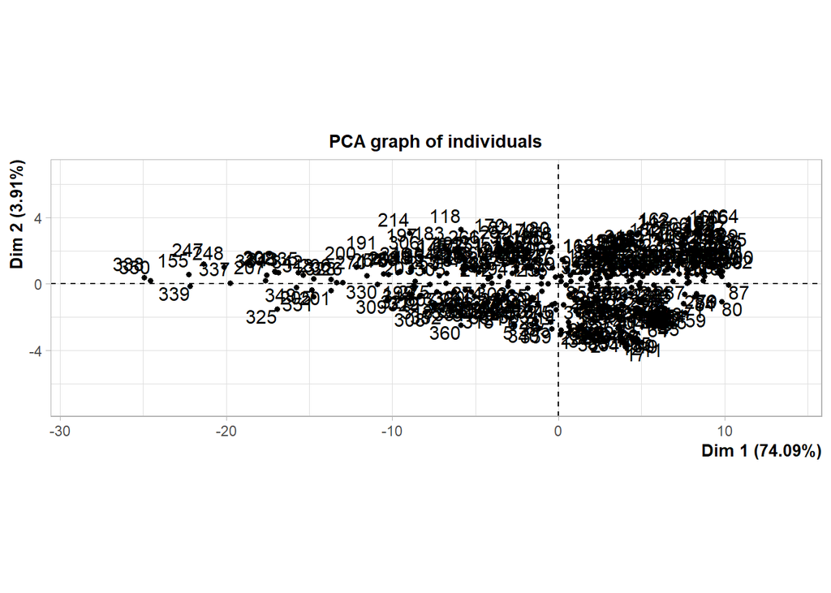

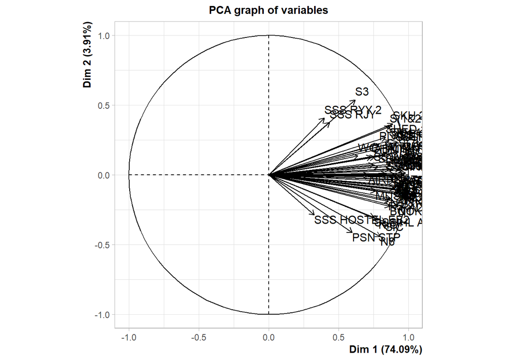

**PCA - Trait statistics**

Package used : agricolae; PB-Perfect

|  | PC1 | PC2 | PC3 | PC4 | PC5 |
| --- | --- | --- | --- | --- | --- |
| Correation between PCs and Traits |  |  |  |  |  |
| SKH 1(MANDIR) | 0.86 | 0.25 | 0.08 | -0.12 | -0.02 |
| SKH 2 | 0.89 | 0.37 | 0.19 | -0.01 | -0.01 |
| N1 | 0.93 | -0.23 | -0.06 | 0.00 | 0.09 |
| N2 | 0.93 | -0.11 | -0.04 | 0.00 | 0.10 |
| N3 &N4 | 0.87 | -0.17 | -0.07 | -0.02 | 0.07 |
| N4 AAC& DAC | 0.97 | -0.14 | -0.03 | -0.03 | 0.05 |
| N5&NAS(CANTEEN) | 0.89 | -0.03 | -0.01 | -0.08 | 0.08 |
| N6 | 0.95 | -0.11 | -0.07 | -0.02 | 0.05 |
| N7 | 0.95 | -0.09 | -0.04 | -0.03 | 0.06 |
| N8 | 0.80 | -0.44 | -0.04 | 0.07 | 0.03 |
| N9 &N9 A | 0.94 | -0.14 | -0.03 | -0.04 | 0.01 |
| R1 | 0.89 | -0.05 | 0.01 | -0.01 | 0.10 |
| R2 | 0.96 | -0.09 | -0.06 | -0.06 | 0.08 |
| R3 | 0.96 | -0.08 | -0.05 | -0.06 | 0.08 |
| R4 | 0.95 | -0.11 | -0.01 | -0.01 | 0.07 |
| R5 | 0.86 | -0.19 | -0.08 | 0.09 | 0.04 |
| W1&2(A) | 0.93 | -0.03 | 0.04 | 0.05 | -0.01 |
| W1&2(B) | 0.87 | 0.04 | 0.12 | 0.08 | -0.12 |
| W 3&4(A) | 0.87 | 0.07 | 0.23 | 0.11 | -0.01 |
| W 3&4(B) | 0.93 | -0.03 | 0.08 | 0.05 | -0.05 |
| W 5&6(A) | 0.92 | -0.08 | -0.07 | -0.05 | 0.11 |
| W 5&6 (B) | 0.98 | 0.07 | 0.02 | -0.04 | 0.02 |
| W 7&8 A | 0.83 | 0.14 | 0.01 | -0.14 | 0.12 |
| W 7&8 B | 0.90 | 0.00 | 0.01 | -0.09 | 0.09 |
| W9 | 0.97 | 0.01 | 0.01 | -0.02 | 0.08 |
| S1 A | 0.96 | 0.07 | 0.03 | -0.04 | -0.02 |
| S1 B | 0.91 | -0.01 | -0.13 | -0.12 | -0.09 |
| S(1&2) | 0.87 | 0.35 | 0.17 | -0.02 | -0.05 |
| S3 | 0.62 | 0.54 | 0.20 | -0.11 | 0.10 |

[output cut: 162 more lines]

Source: JBS Research Lab

#### 2.3.0.15 Quality of Representation of Traits on PCs

1. **Strong Representation on PC1**:
   - **High Values**: Traits like N4 AAC & DAC (0.94), N6 (0.90), R3 (0.93), W 5&6 (B) (0.95), and S1 A (0.92) have high values on PC1, suggesting they are well-represented by the first principal component.
   - **Broad Influence**: This broad influence indicates that PC1 captures the major variations in the dataset.
2. **Moderate to Low Representation on PC2 to PC5**:
   - **Lower Values**: Traits generally have lower values on PC2 to PC5, indicating these components capture more specific, less dominant variations in the data.

#### 2.3.0.16 Contributions (%) of the Traits to the Principal Components

1. **Significant Contributors to PC1**:
   - **Key Traits**: N4 AAC & DAC (2.07%), R3 (2.05%), W 5&6 (B) (2.11%), and LADIES SEVADAL (2.07%) contribute significantly to PC1, highlighting their importance in the overall variance explained by this component.
2. **Distinctive Contributions to Other PCs**:
   - **PC2**: N8 (7.86%), S3 (12.15%), PSN STP (8.67%), and SSS RYY 2 (9.74%) are notable for their higher contributions to PC2.
   - **PC3 and Beyond**: Specific traits like S3 (4.77% to PC3) and SSS HOSTEL EB2 (25.35% to PC3) show significant contributions, indicating their unique influence captured by these components.

#### 2.3.0.17 Insights on Specific Areas

1. **High Performing Areas**:
   - **N1 to N7**: Consistently show high correlations and contributions, indicating robust performance in these regions.
   - **W5&6 and S1 A**: High values and contributions suggest strong performance and significant variance explanation in these areas.
2. **Areas with Specific Influences**:
   - **PSN STP**: Notable contributions to PC3 and PC4 suggest specific factors affecting this area uniquely.
   - **SSS HOSTEL EB2**: High contribution to PC3 (25.35%) highlights unique influences or variations in this area.

# 3 Temporal Trends and Variability in Solar Energy Data across Multiple Locations

### 3.0.1 Analysis of Daily and Weekly Heatmaps

In this section, we present two heatmaps to visualize the daily and weekly average unit readings across various areas. These visualizations provide insights into temporal patterns and variations in unit measurements.

#### 3.0.1.1 Daily Readings Heatmap

The heatmap depicts the daily & Weekly average unit readings for different areas respectively.

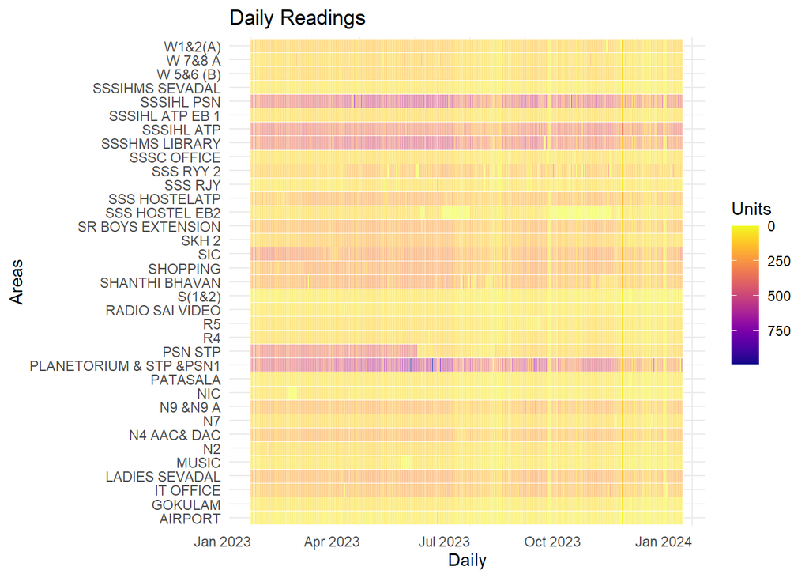

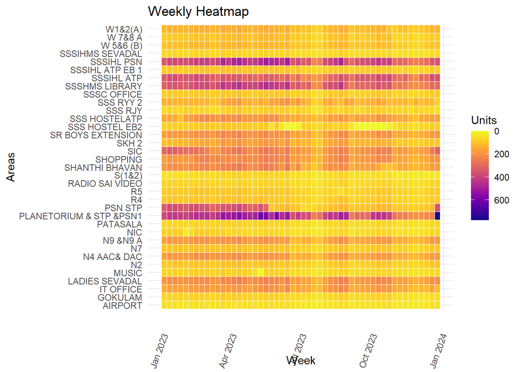